# Analysis_birdsdata

Cheyenne, Kathina & Lina

4/7/2021

This document have been created to include all relevant parts in the analysis of our animal diversity project.

##Data preparation and data observation

The first code’s chunk will be used to load all libraries needed to proceed.

```r
library(tidyverse)
library(vegan)
library(nlme)
library(MASS)
library(MuMIn)
#?rowSums
#?r.squar
```

In this second chunk, the data to be used will be loaded into a data frame and transferred into adequate data types.

```r
dat <- read.csv("data/birds_dataset.csv", sep=";")
# parks <- read.csv("data/parks.csv", sep=";")
# forest <- read.csv("data/forest.csv", sep=";") obsolete due to creation of subsamples below
dat$category <- as.factor(dat$category)
dat$site <- as.factor(dat$site)
```

Following, species richness, species abundance and rarefied richness of species will be calculated.

```r
dat$species_richness <- specnumber(dat[,4:31]) #species richness
dat$species_abund <- rowSums(dat[,4:31]) #abundances
dat$rarefied_richness <- rarefy(dat[,4:31],min(dat$species_abund)) #rarefied richness based on the subsample with the lowest number of individuals
```

subsets for forest and park + median, mean, min max…

```r
forest <- subset(dat, category=="forest")
park <- subset(dat, category=="park")
median(forest$species_abund)
```

```
## [1] 16
```

```r
median(park$species_abund)
```

```
## [1] 24
```

After, data is observed comparing the plots from parks and forests.

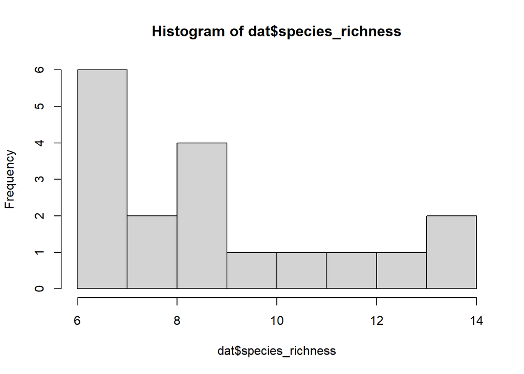

```r
hist(dat$species_richness) # not normally distributed
```

```r
kruskal.test(dat$species_richness, dat$category) #p-value = 0.01533
```

```
##
##  Kruskal-Wallis rank sum test
##
## data:  dat$species_richness and dat$category
## Kruskal-Wallis chi-squared = 5.8783, df = 1, p-value = 0.01533
```

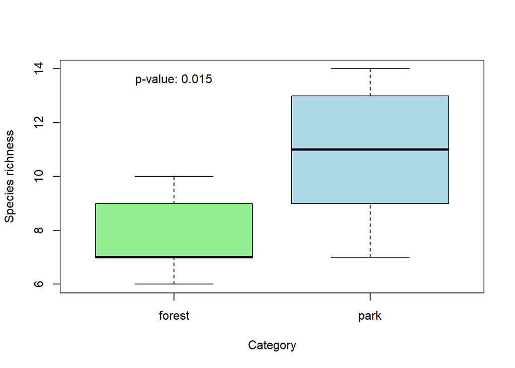

```r
boxplot(species_richness~category, data=dat, xlab= "Category", ylab= "Species richness", col= c("lightgreen", "lightblue"))
text(1,13.6,labels = "p-value: 0.015", cex = 1)
```

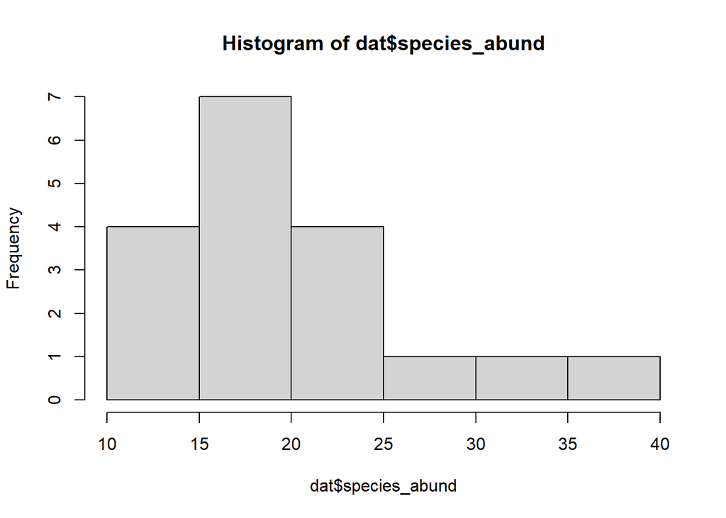

```r
hist(dat$species_abund) # not normally distributed
```

```r
kruskal.test(dat$species_abund, dat$category) #p-value = 0.0046
```

```
##
##  Kruskal-Wallis rank sum test
##
## data:  dat$species_abund and dat$category
## Kruskal-Wallis chi-squared = 8.0175, df = 1, p-value = 0.004633
```

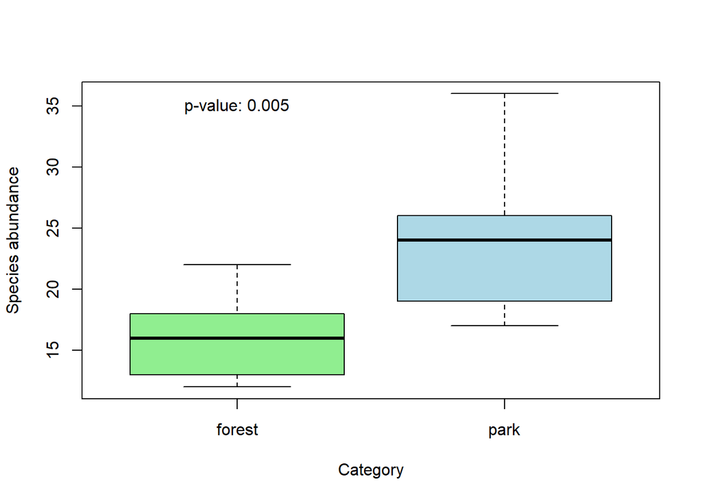

```r
boxplot(species_abund~category, data=dat, xlab= "Category", ylab= "Species abundance", col= c("lightgreen", "lightblue"))
text(1,35,labels = "p-value: 0.005", cex = 1)
```

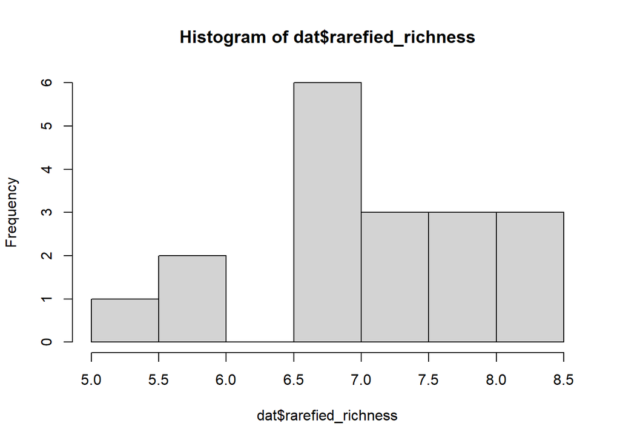

```r
hist(dat$rarefied_richness) # normally distributed
```

```r
mod<-aov(dat$rarefied_richness ~ dat$category)
summary(mod) #p-value: 0.291
```

```
##              Df Sum Sq Mean Sq F value Pr(>F)
## dat$category  1  0.941  0.9405   1.194  0.291
## Residuals    16 12.605  0.7878
```

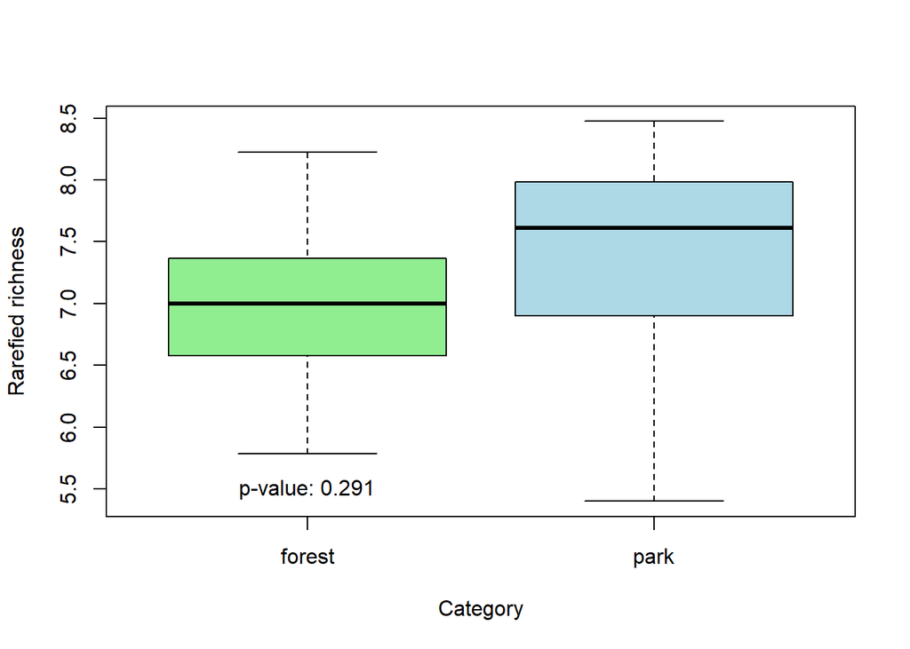

```r
boxplot(rarefied_richness~category, data=dat, xlab= "Category", ylab= "Rarefied richness", col= c("lightgreen", "lightblue"))
text(1,5.5,labels = "p-value: 0.291", cex = 1)
```

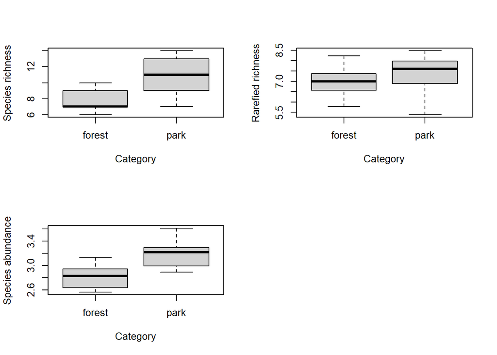

```r
layout(matrix(c(1:4), nrow=2, byrow=FALSE))
boxplot(species_richness~category, data=dat, xlab= "Category", ylab= "Species richness")
boxplot(log(species_abund+1)~category, data=dat, xlab= "Category", ylab= "Species abundance")
#?boxplot
boxplot(rarefied_richness~category, data=dat, xlab= "Category", ylab= "Rarefied richness")
layout(matrix(c(1:4), nrow=2, byrow=FALSE))
```

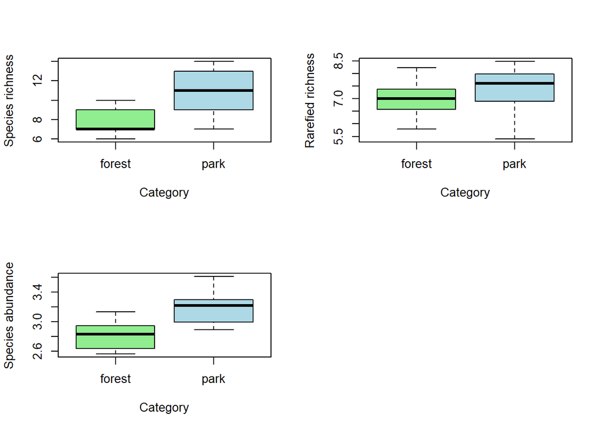

```r
boxplot(species_richness~category, data=dat, xlab= "Category", ylab= "Species richness", col= c("lightgreen", "lightblue"))
boxplot(log(species_abund+1)~category, data=dat, xlab= "Category", ylab= "Species abundance", col= c("lightgreen", "lightblue"))
#?boxplot
boxplot(rarefied_richness~category, data=dat, xlab= "Category", ylab= "Rarefied richness", col= c("lightgreen", "lightblue"))
```

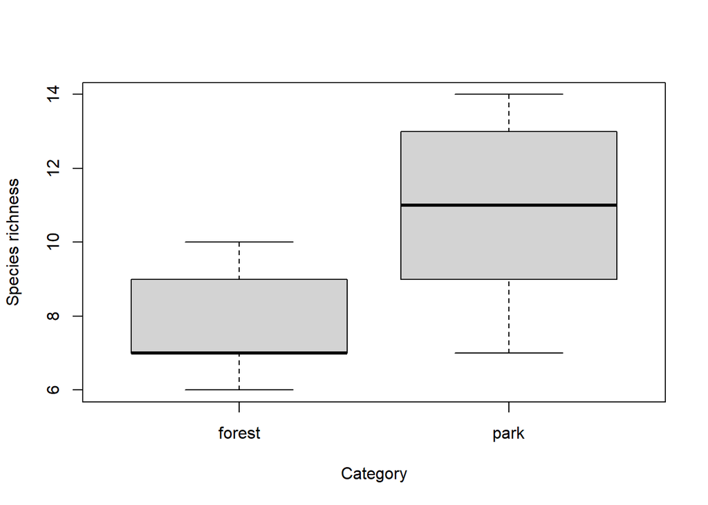

```r
boxplot(species_richness~category, data=dat, xlab= "Category", ylab= "Species richness")
```

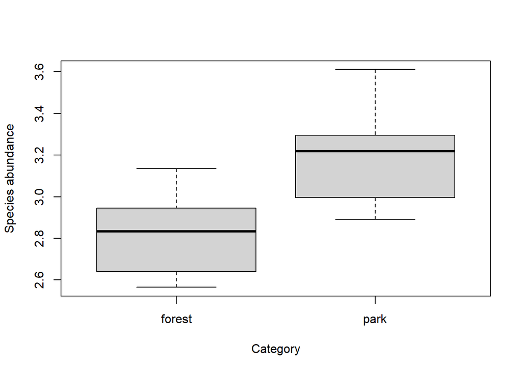

```r
boxplot(log(species_abund+1)~category, data=dat, xlab= "Category", ylab= "Species abundance")
```

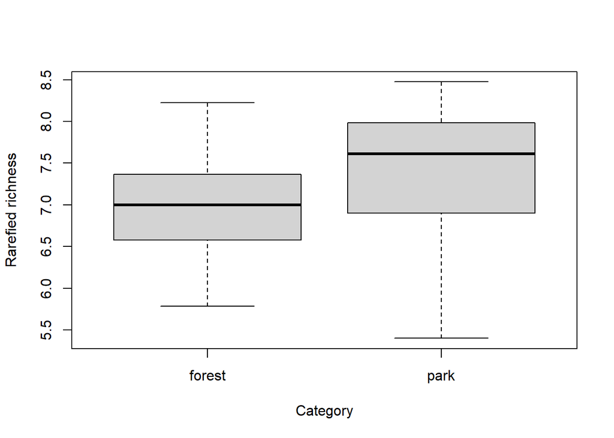

```r
#?boxplot
boxplot(rarefied_richness~category, data=dat, xlab= "Category", ylab= "Rarefied richness")
```

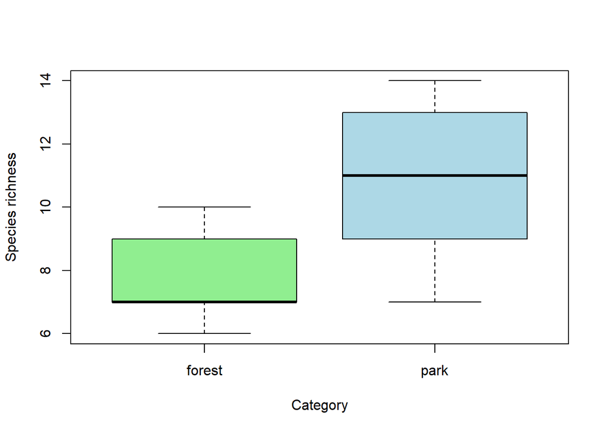

```r
boxplot(species_richness~category, data=dat, xlab= "Category", ylab= "Species richness", col= c("lightgreen", "lightblue"))
```

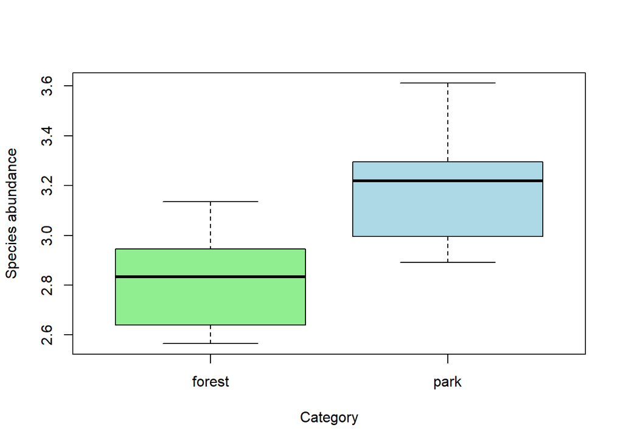

```r
boxplot(log(species_abund+1)~category, data=dat, xlab= "Category", ylab= "Species abundance", col= c("lightgreen", "lightblue"))
```

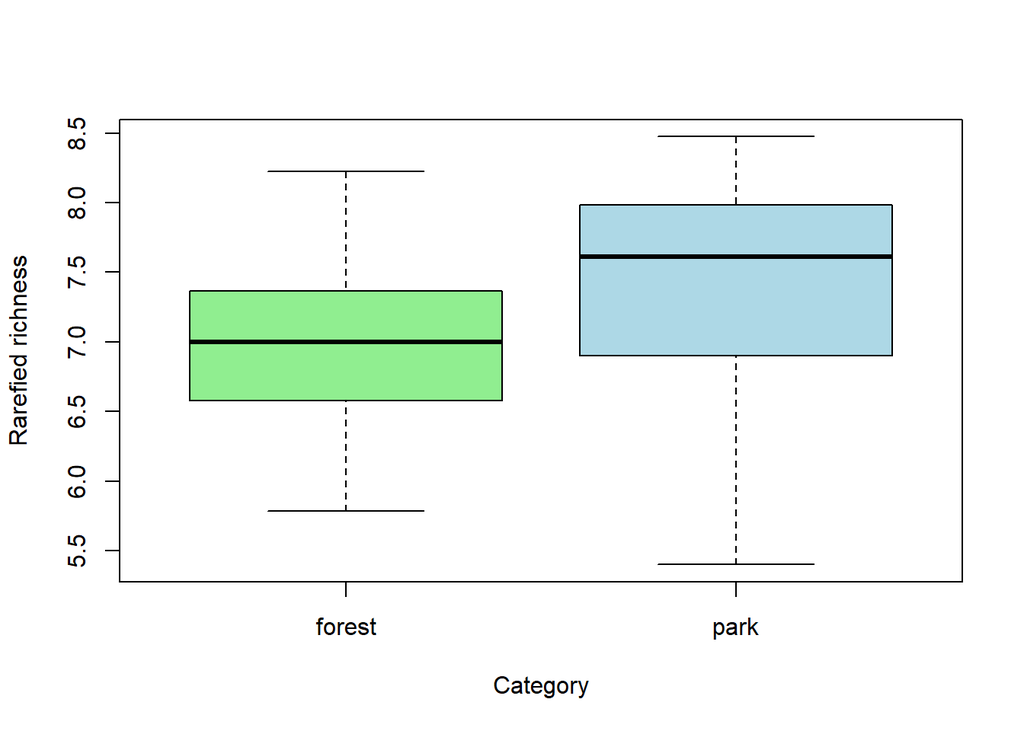

```r
#?boxplot
boxplot(rarefied_richness~category, data=dat, xlab= "Category", ylab= "Rarefied richness", col= c("lightgreen", "lightblue"))
```

##Now let’s begin with the data analysis

#2a linear models: to check for difference between habitat types with the implementation of mixed effect models.

```r
mod1 <- lme(species_richness~category, random = (~1|site), data=dat) #model structure, random=... specifies how the data are structured (subsamples nested in study site)
summary(mod1) #model output - important is the "fixed effects" part. Here "forest" is hiding in the "Intercept" and the categorypark-row is showing the difference between park and forest
```

```
## Linear mixed-effects model fit by REML
##   Data: dat
##        AIC     BIC    logLik
##   78.65584 81.7462 -35.32792
##
## Random effects:
##  Formula: ~1 | site
##         (Intercept) Residual
## StdDev:    1.459325 1.649916
##
## Fixed effects:  species_richness ~ category
##                 Value Std.Error DF  t-value p-value
## (Intercept)  7.777778  1.006154 12 7.730207  0.0000
## categorypark 3.000000  1.422916  4 2.108346  0.1027
##  Correlation:
##              (Intr)
## categorypark -0.707
##
## Standardized Within-Group Residuals:
##        Min         Q1        Med         Q3        Max
## -1.5969444 -0.5205776 -0.1919700  0.8175666  1.4335132
##
## Number of Observations: 18
## Number of Groups: 6
```

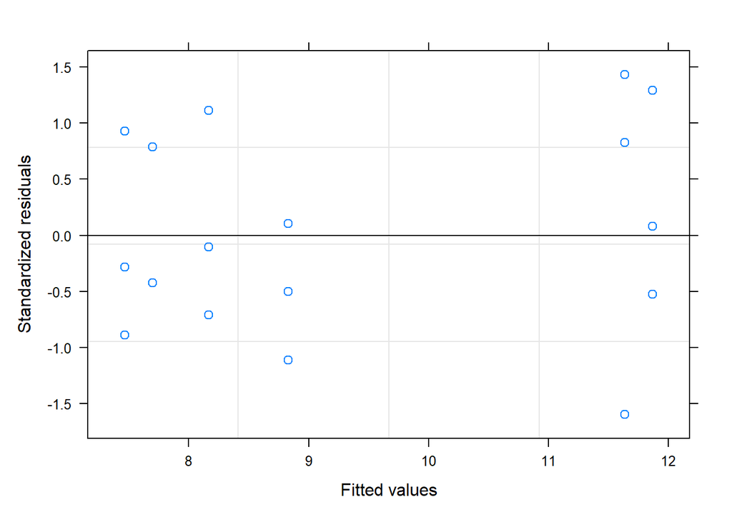

```r
plot(mod1) #check for homogeneity of variances (data points should have similar vertical spread along the x-axis)
```

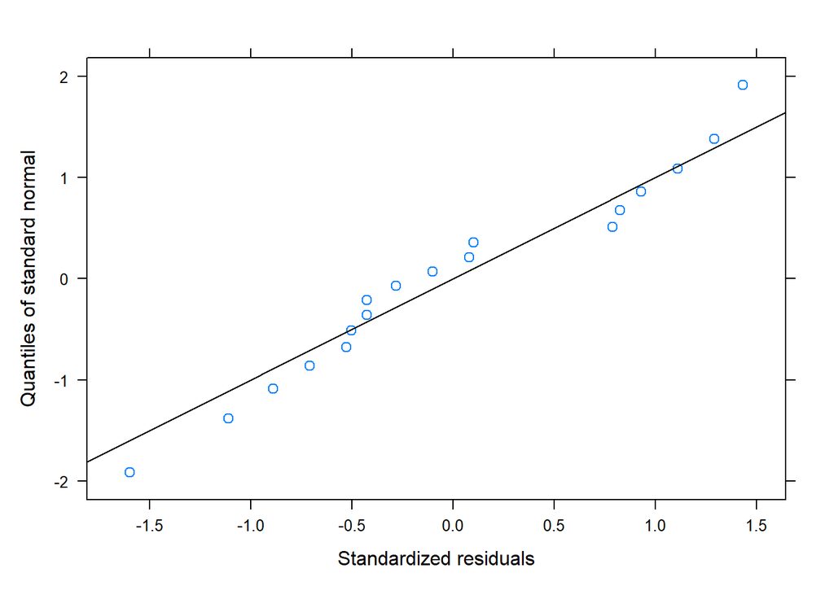

```r
qqnorm(mod1, ~resid(.,type="p"), abline = c(0,1)) #check for normality of residuals (should not be completely off the line)
```

#2b linear models to include environmental variables and see the variation of the data with each of them.

```r
### MIXED EFFECTS MODEL WITH SPECIES RICHNESS

round(cor(dat[,32:45]),2) #check which predictor variables are strongly correlated (below -0.7 or above 0.7) - highly correlated variables should not be included together in the same model (select only one of them, e.g. the one more strongly related to the response variable)
```

```
##                 canopy_cover n_tree_spec n_tree_ind dbh_min dbh_min5 dbh_mean
## canopy_cover            1.00       -0.68       0.22   -0.43    -0.38    -0.42
## n_tree_spec            -0.68        1.00      -0.42    0.30     0.18     0.31
## n_tree_ind              0.22       -0.42       1.00   -0.12    -0.51    -0.49
## dbh_min                -0.43        0.30      -0.12    1.00     0.37     0.68
## dbh_min5               -0.38        0.18      -0.51    0.37     1.00     0.71
## dbh_mean               -0.42        0.31      -0.49    0.68     0.71     1.00
## dbh_max                -0.33        0.23      -0.52    0.26     0.57     0.83
## dbh_median             -0.29        0.29      -0.56    0.30     0.89     0.74
## dbh_sd                 -0.69        0.78      -0.63    0.09     0.39     0.36
## n_microhabitats         0.30       -0.42      -0.12   -0.06     0.44     0.27
## latitude                0.30       -0.60       0.22   -0.23     0.04    -0.08
## longitude               0.71       -0.64       0.32   -0.57    -0.50    -0.42
## size                    0.64       -0.52       0.35   -0.33    -0.55    -0.52
## temperature            -0.02        0.03       0.44   -0.29    -0.49    -0.26
##                 dbh_max dbh_median dbh_sd n_microhabitats latitude longitude
## canopy_cover      -0.33      -0.29  -0.69            0.30     0.30      0.71
## n_tree_spec        0.23       0.29   0.78           -0.42    -0.60     -0.64
## n_tree_ind        -0.52      -0.56  -0.63           -0.12     0.22      0.32
## dbh_min            0.26       0.30   0.09           -0.06    -0.23     -0.57
## dbh_min5           0.57       0.89   0.39            0.44     0.04     -0.50
## dbh_mean           0.83       0.74   0.36            0.27    -0.08     -0.42
## dbh_max            1.00       0.57   0.47            0.14     0.03     -0.19
## dbh_median         0.57       1.00   0.44            0.49    -0.06     -0.39
## dbh_sd             0.47       0.44   1.00           -0.32    -0.40     -0.58
## n_microhabitats    0.14       0.49  -0.32            1.00     0.30      0.21
## latitude           0.03      -0.06  -0.40            0.30     1.00      0.14
## longitude         -0.19      -0.39  -0.58            0.21     0.14      1.00
## size              -0.52      -0.48  -0.61            0.22    -0.09      0.80
## temperature       -0.06      -0.38  -0.02           -0.45     0.05      0.23
##                  size temperature
## canopy_cover     0.64       -0.02
## n_tree_spec     -0.52        0.03
## n_tree_ind       0.35        0.44
## dbh_min         -0.33       -0.29
## dbh_min5        -0.55       -0.49
## dbh_mean        -0.52       -0.26
## dbh_max         -0.52       -0.06
## dbh_median      -0.48       -0.38
## dbh_sd          -0.61       -0.02
## n_microhabitats  0.22       -0.45
## latitude        -0.09        0.05
## longitude        0.80        0.23
## size             1.00       -0.07
## temperature     -0.07        1.00
```

```r
mod2 <- lme(species_richness ~ category*size + canopy_cover + n_tree_spec + n_tree_ind + dbh_mean + n_microhabitats + temperature, random = (~1|site), data=dat, method="ML") #initial, full model with all potential predictor variables
summary(mod2)
```

```
## Linear mixed-effects model fit by maximum likelihood
##   Data: dat
##        AIC      BIC    logLik
##   78.15111 88.83557 -27.07555
##
## Random effects:
##  Formula: ~1 | site
##          (Intercept) Residual
## StdDev: 2.203848e-05 1.088999
##
## Fixed effects:  species_richness ~ category * size + canopy_cover + n_tree_spec +      n_tree_ind + dbh_mean + n_microhabitats + temperature
##                       Value Std.Error DF   t-value p-value
## (Intercept)       15.944431  4.962963  7  3.212684  0.0148
## categorypark      -0.929198  2.765989  1 -0.335937  0.7937
## size              -0.004414  0.011233  1 -0.392967  0.7616
## canopy_cover      -0.043150  0.026056  7 -1.656089  0.1417
## n_tree_spec       -0.396169  0.318390  7 -1.244288  0.2534
## n_tree_ind         0.015184  0.153805  7  0.098722  0.9241
## dbh_mean           0.054217  0.028035  7  1.933885  0.0944
## n_microhabitats   -0.071704  0.088881  7 -0.806747  0.4464
## temperature       -0.262180  0.164449  1 -1.594289  0.3566
## categorypark:size  0.065564  0.053671  1  1.221589  0.4367
##  Correlation:
##                   (Intr) ctgryp size   cnpy_c n_tr_s n_tr_n dbh_mn n_mcrh
## categorypark      -0.450
## size              -0.383  0.726
## canopy_cover      -0.622  0.338  0.026
## n_tree_spec       -0.316 -0.403 -0.319  0.131
## n_tree_ind        -0.497  0.146 -0.036  0.142  0.430
## dbh_mean          -0.151 -0.473 -0.134  0.020  0.173  0.126
## n_microhabitats   -0.304  0.196  0.084  0.068  0.013 -0.148 -0.412
## temperature       -0.306  0.294  0.358  0.148 -0.408 -0.528 -0.126  0.504
## categorypark:size -0.004 -0.164 -0.054  0.196 -0.348 -0.514  0.102  0.324
##                   tmprtr
## categorypark
## size
## canopy_cover
## n_tree_spec
## n_tree_ind
## dbh_mean
## n_microhabitats
## temperature
## categorypark:size  0.544
##
## Standardized Within-Group Residuals:
##        Min         Q1        Med         Q3        Max
## -1.7168405 -0.6187248 -0.1021469  0.7833831  2.2863006
##
## Number of Observations: 18
## Number of Groups: 6
```

```r
mod2.1 <- stepAIC(mod2) #model simplification based on AIC-value of the model
```

```
## Start:  AIC=78.15
## species_richness ~ category * size + canopy_cover + n_tree_spec +
##     n_tree_ind + dbh_mean + n_microhabitats + temperature
##
##                   Df    AIC
## - n_tree_ind       1 76.173
## - n_microhabitats  1 77.559
## <none>               78.151
## - category:size    1 79.230
## - n_tree_spec      1 79.336
## - temperature      1 81.117
## - canopy_cover     1 81.457
## - dbh_mean         1 83.055
##
## Step:  AIC=76.17
## species_richness ~ category + size + canopy_cover + n_tree_spec +
##     dbh_mean + n_microhabitats + temperature + category:size
##
##                   Df    AIC
## - n_microhabitats  1 75.560
## <none>               76.173
## - n_tree_spec      1 78.242
## - category:size    1 78.540
## - canopy_cover     1 79.647
## - temperature      1 80.376
## - dbh_mean         1 81.088
##
## Step:  AIC=75.56
## species_richness ~ category + size + canopy_cover + n_tree_spec +
##     dbh_mean + temperature + category:size
##
##                 Df    AIC
## <none>             75.560
## - n_tree_spec    1 77.056
## - canopy_cover   1 78.333
## - temperature    1 78.407
## - dbh_mean       1 79.089
## - category:size  1 79.262
```

```r
summary(mod2.1) #final model which includes only the most important predictors
```

```
## Linear mixed-effects model fit by maximum likelihood
##   Data: dat
##        AIC      BIC    logLik
##   75.55985 84.46357 -27.77993
##
## Random effects:
##  Formula: ~1 | site
##          (Intercept) Residual
## StdDev: 2.226226e-05 1.132458
##
## Fixed effects:  species_richness ~ category + size + canopy_cover + n_tree_spec +      dbh_mean + temperature + category:size
##                       Value Std.Error DF   t-value p-value
## (Intercept)       14.672137  3.597092  9  4.078889  0.0028
## categorypark      -0.482896  2.481824  1 -0.194573  0.8777
## size              -0.003663  0.010409  1 -0.351878  0.7846
## canopy_cover      -0.041630  0.023889  9 -1.742664  0.1154
## n_tree_spec       -0.390018  0.266364  9 -1.464233  0.1772
## dbh_mean           0.044942  0.023700  9  1.896307  0.0904
## temperature       -0.196868  0.111988  1 -1.757941  0.3293
## categorypark:size  0.079072  0.040958  1  1.930546  0.3043
##  Correlation:
##                   (Intr) ctgryp size   cnpy_c n_tr_s dbh_mn tmprtr
## categorypark      -0.391
## size              -0.477  0.743
## canopy_cover      -0.673  0.312  0.025
## n_tree_spec       -0.104 -0.556 -0.345  0.071
## dbh_mean          -0.339 -0.461 -0.109  0.043  0.183
## temperature       -0.708  0.391  0.418  0.255 -0.326  0.168
## categorypark:size -0.256 -0.183 -0.113  0.305 -0.199  0.357  0.275
##
## Standardized Within-Group Residuals:
##         Min          Q1         Med          Q3         Max
## -1.25367764 -1.00232732 -0.09062601  0.80538278  2.22429975
##
## Number of Observations: 18
## Number of Groups: 6
```

```r
mod2.2 <- update(mod2.1, ~.-n_tree_spec)
summary(mod2.2)
```

```
## Linear mixed-effects model fit by maximum likelihood
##   Data: dat
##        AIC      BIC    logLik
##   77.05632 85.06967 -29.52816
##
## Random effects:
##  Formula: ~1 | site
##          (Intercept) Residual
## StdDev: 4.567893e-05 1.247966
##
## Fixed effects:  species_richness ~ category + size + canopy_cover + dbh_mean +      temperature + category:size
##                       Value Std.Error DF   t-value p-value
## (Intercept)       14.124851  3.759052 10  3.757557  0.0037
## categorypark      -2.502864  2.167710  1 -1.154612  0.4544
## size              -0.008924  0.010265  1 -0.869357  0.5444
## canopy_cover      -0.039147  0.025037 10 -1.563569  0.1490
## dbh_mean           0.051287  0.024482 10  2.094917  0.0626
## temperature       -0.250281  0.111250  1 -2.249714  0.2663
## categorypark:size  0.067136  0.042174  1  1.591857  0.3571
##  Correlation:
##                   (Intr) ctgryp size   cnpy_c dbh_mn tmprtr
## categorypark      -0.543
## size              -0.550  0.707
## canopy_cover      -0.671  0.424  0.052
## dbh_mean          -0.327 -0.440 -0.049  0.030
## temperature       -0.788  0.267  0.344  0.295  0.245
## categorypark:size -0.284 -0.360 -0.198  0.326  0.409  0.226
##
## Standardized Within-Group Residuals:
##         Min          Q1         Med          Q3         Max
## -1.28014570 -0.71138298 -0.04444658  0.61471701  2.93583839
##
## Number of Observations: 18
## Number of Groups: 6
```

```r
anova(mod2.1, mod2.2)
```

```
##        Model df      AIC      BIC    logLik   Test  L.Ratio p-value
## mod2.1     1 10 75.55985 84.46357 -27.77993
## mod2.2     2  9 77.05632 85.06967 -29.52816 1 vs 2 3.496468  0.0615
```

```r
mod2.3 <- update(mod2.2, ~.-temperature)
summary(mod2.3)
```

```
## Linear mixed-effects model fit by maximum likelihood
##   Data: dat
##        AIC      BIC    logLik
##   81.24597 88.36895 -32.62299
##
## Random effects:
##  Formula: ~1 | site
##         (Intercept) Residual
## StdDev:   0.7123422 1.337547
##
## Fixed effects:  species_richness ~ category + size + canopy_cover + dbh_mean +      category:size
##                       Value Std.Error DF    t-value p-value
## (Intercept)        7.911823 2.7719285 10  2.8542667  0.0171
## categorypark      -0.894240 2.6336485  2 -0.3395443  0.7665
## size              -0.000363 0.0133808  2 -0.0271586  0.9808
## canopy_cover      -0.025692 0.0252733 10 -1.0165801  0.3333
## dbh_mean           0.056032 0.0248361 10  2.2560678  0.0477
## categorypark:size  0.081131 0.0545162  2  1.4881982  0.2751
##  Correlation:
##                   (Intr) ctgryp size   cnpy_c dbh_mn
## categorypark      -0.642
## size              -0.603  0.728
## canopy_cover      -0.662  0.306 -0.044
## dbh_mean          -0.208 -0.443 -0.112 -0.027
## categorypark:size -0.058 -0.470 -0.286  0.228  0.299
##
## Standardized Within-Group Residuals:
##        Min         Q1        Med         Q3        Max
## -1.4009901 -0.6062604 -0.3551229  0.8345446  1.9542540
##
## Number of Observations: 18
## Number of Groups: 6
```

```r
anova(mod2.2, mod2.3) #close to significcance effect with these variables (species increasing with increasing dbh min.)
```

```
##        Model df      AIC      BIC    logLik   Test  L.Ratio p-value
## mod2.2     1  9 77.05632 85.06967 -29.52816
## mod2.3     2  8 81.24597 88.36895 -32.62299 1 vs 2 6.189652  0.0128
```

```r
mod2.4 <- update(mod2.3, ~.-canopy_cover)
summary(mod2.4)
```

```
## Linear mixed-effects model fit by maximum likelihood
##   Data: dat
##        AIC      BIC    logLik
##   80.62485 86.85746 -33.31243
##
## Random effects:
##  Formula: ~1 | site
##         (Intercept) Residual
## StdDev:   0.5501961 1.450565
##
## Fixed effects:  species_richness ~ category + size + dbh_mean + category:size
##                       Value Std.Error DF    t-value p-value
## (Intercept)        5.972462 1.9284808 11  3.0969775  0.0102
## categorypark      -0.211366 2.3623694  2 -0.0894720  0.9369
## size              -0.001142 0.0122712  2 -0.0930443  0.9343
## dbh_mean           0.058328 0.0256868 11  2.2707419  0.0442
## categorypark:size  0.095737 0.0492991  2  1.9419555  0.1916
##  Correlation:
##                   (Intr) ctgryp size   dbh_mn
## categorypark      -0.555
## size              -0.823  0.771
## dbh_mean          -0.336 -0.502 -0.127
## categorypark:size  0.098 -0.597 -0.289  0.349
##
## Standardized Within-Group Residuals:
##        Min         Q1        Med         Q3        Max
## -1.3908435 -0.6172619 -0.2637441  0.6458412  2.1303554
##
## Number of Observations: 18
## Number of Groups: 6
```

```r
anova(mod2.3,mod2.4)
```

```
##        Model df      AIC      BIC    logLik   Test  L.Ratio p-value
## mod2.3     1  8 81.24597 88.36895 -32.62299
## mod2.4     2  7 80.62485 86.85746 -33.31243 1 vs 2 1.378879  0.2403
```

```r
#final model:
#lme(species_richness ~ log(dbh_min), random = (~1|site), data=dat, method="ML")
#https://jonlefcheck.net/2013/03/13/r2-for-linear-mixed-effects-models/
r.squaredGLMM(mod2.4)
```

```
##           R2m       R2c
## [1,] 0.607788 0.6571174
```

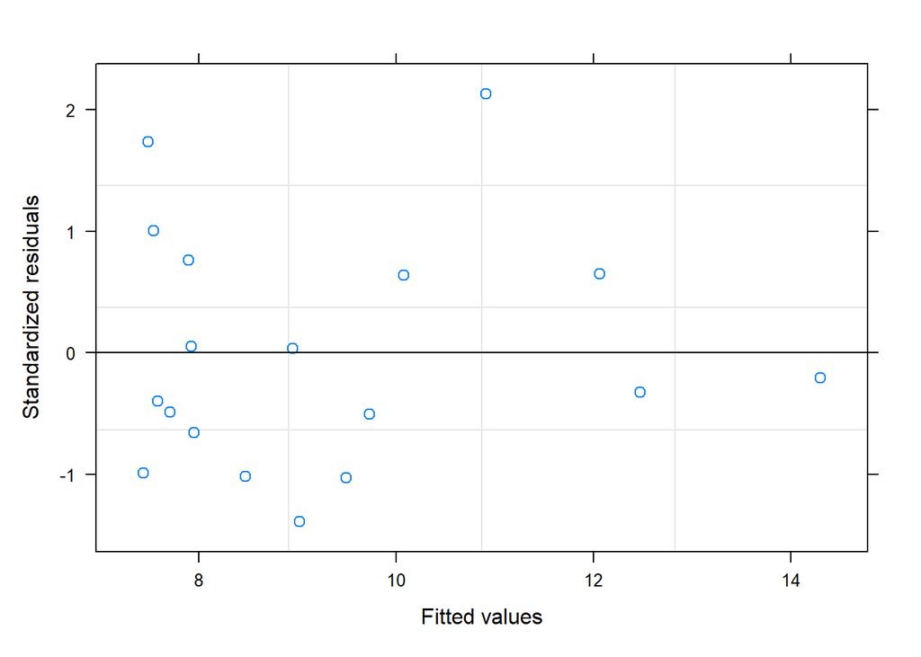

```r
plot(mod2.4) #check for homogeneity of variances (data points should have similar vertical spread along the x-axis)
```

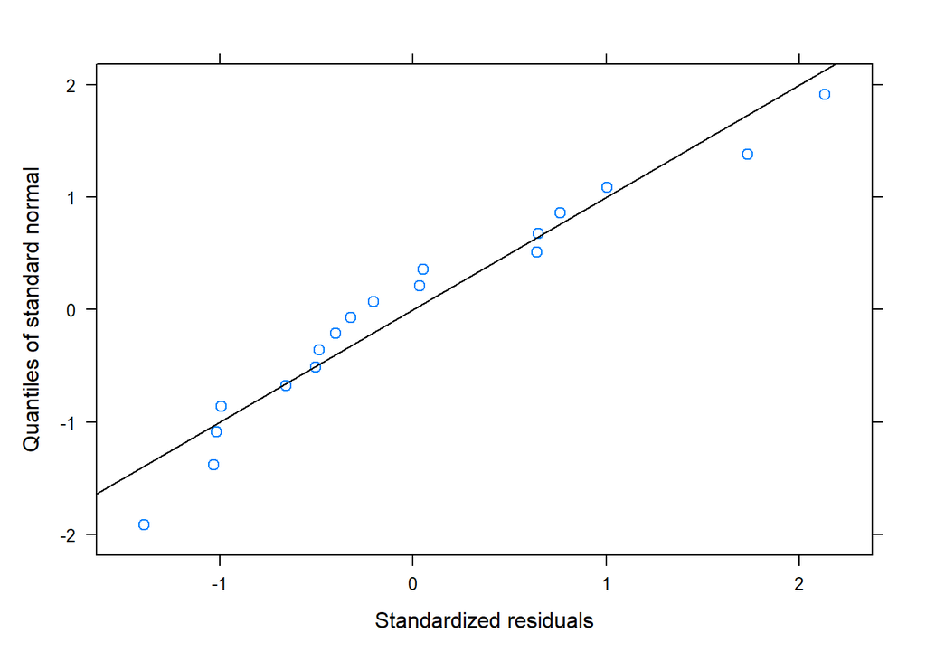

```r
qqnorm(mod2.4, ~resid(.,type="p"), abline=c(0,1)) #check for normality of residuals (should not be completely off the line)
```

```r
#standard deviation, coefficient of variation (sd/mean) to make variation independent from out mean value of dbh_mean in this case, and check whether is correlated with the other variables and if this is the case we would need to include it in mod2 and check correlation with (vif for the model)  and cor for correlation

#dat$sddbh_mean <- sd() we can try as alternative
library(car)
vif(mod2.2)
```

```
##      category          size  canopy_cover      dbh_mean   temperature
##      8.297162      4.108259      3.093743      2.163964      1.418070
## category:size
##      2.117245
```

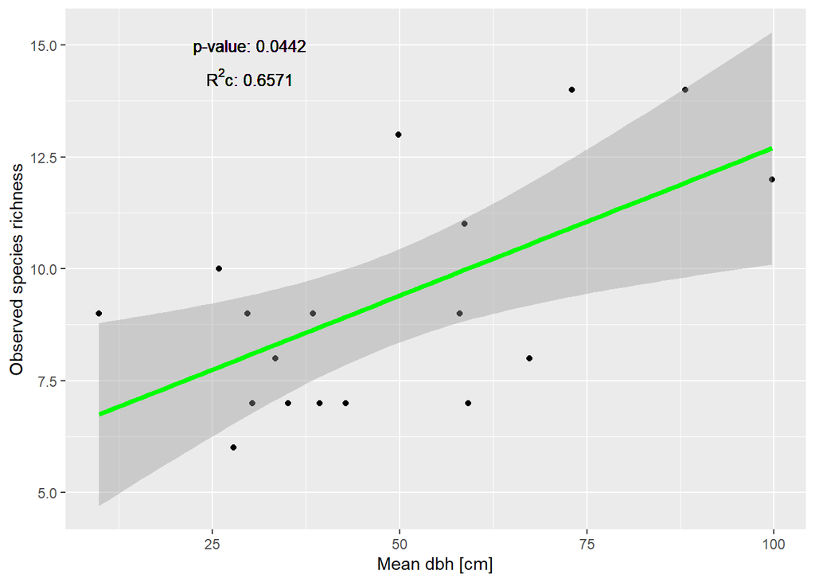

```r
ggplot(dat, aes(x = dbh_mean, y = species_richness))+
  geom_point() +
  geom_smooth(method = lm,se = TRUE, colour = 'green', size = 1.5) +geom_text(x=30, y=15, label="p-value: 0.0442", size=3.5) +
  geom_text(x=30,y=14.3,label=expression(paste("R"^2,"c: 0.6571")), size=3.5) +
  labs(x="Mean dbh [cm]", y="Observed species richness")
```

#2c Linear Mixed Effect models

```r
### MIXED EFFECTS MODEL WITH BIRD ABUNDANCE
mod3.1 <- lme(species_abund ~ category*size + canopy_cover + n_tree_spec + n_tree_ind + dbh_mean + n_microhabitats + temperature, random = (~1|site), data=dat, method="ML") #initial, full model with all potential predictor variables
summary(mod3.1)
```

```
## Linear mixed-effects model fit by maximum likelihood
##   Data: dat
##        AIC      BIC    logLik
##   108.9707 119.6552 -42.48537
##
## Random effects:
##  Formula: ~1 | site
##          (Intercept) Residual
## StdDev: 5.560504e-05 2.563465
##
## Fixed effects:  species_abund ~ category * size + canopy_cover + n_tree_spec +      n_tree_ind + dbh_mean + n_microhabitats + temperature
##                      Value Std.Error DF    t-value p-value
## (Intercept)       32.60464 11.682637  7  2.7908627  0.0269
## categorypark      -0.52111  6.511040  1 -0.0800347  0.9492
## size              -0.02546  0.026443  1 -0.9629817  0.5120
## canopy_cover      -0.11203  0.061334  7 -1.8265403  0.1105
## n_tree_spec       -0.56638  0.749478  7 -0.7557020  0.4745
## n_tree_ind         0.03783  0.362051  7  0.1044876  0.9197
## dbh_mean           0.09032  0.065994  7  1.3685725  0.2134
## n_microhabitats    0.20644  0.209222  7  0.9867270  0.3566
## temperature       -0.48986  0.387107  1 -1.2654403  0.4257
## categorypark:size  0.01948  0.126341  1  0.1541849  0.9026
##  Correlation:
##                   (Intr) ctgryp size   cnpy_c n_tr_s n_tr_n dbh_mn n_mcrh
## categorypark      -0.450
## size              -0.383  0.726
## canopy_cover      -0.622  0.338  0.026
## n_tree_spec       -0.316 -0.403 -0.319  0.131
## n_tree_ind        -0.497  0.146 -0.036  0.142  0.430
## dbh_mean          -0.151 -0.473 -0.134  0.020  0.173  0.126
## n_microhabitats   -0.304  0.196  0.084  0.068  0.013 -0.148 -0.412
## temperature       -0.306  0.294  0.358  0.148 -0.408 -0.528 -0.126  0.504
## categorypark:size -0.004 -0.164 -0.054  0.196 -0.348 -0.514  0.102  0.324
##                   tmprtr
## categorypark
## size
## canopy_cover
## n_tree_spec
## n_tree_ind
## dbh_mean
## n_microhabitats
## temperature
## categorypark:size  0.544
##
## Standardized Within-Group Residuals:
##        Min         Q1        Med         Q3        Max
## -1.8191889 -0.7463000 -0.1139194  0.8415455  1.7553733
##
## Number of Observations: 18
## Number of Groups: 6
```

```r
mod3.2 <- stepAIC(mod3.1) #model simplification based on AIC-value of the model
```

```
## Start:  AIC=108.97
## species_abund ~ category * size + canopy_cover + n_tree_spec +
##     n_tree_ind + dbh_mean + n_microhabitats + temperature
##
##                   Df    AIC
## - n_tree_ind       1 107.00
## - category:size    1 107.02
## - n_tree_spec      1 108.21
## <none>               108.97
## - n_microhabitats  1 109.04
## - temperature      1 110.25
## - dbh_mean         1 110.76
## - canopy_cover     1 113.25
##
## Step:  AIC=107
## species_abund ~ category + size + canopy_cover + n_tree_spec +
##     dbh_mean + n_microhabitats + temperature + category:size
##
##                   Df    AIC
## - category:size    1 105.13
## - n_tree_spec      1 106.68
## <none>               107.00
## - n_microhabitats  1 107.17
## - dbh_mean         1 108.77
## - temperature      1 109.06
## - canopy_cover     1 111.46
##
## Step:  AIC=105.13
## species_abund ~ category + size + canopy_cover + n_tree_spec +
##     dbh_mean + n_microhabitats + temperature
##
##                   Df    AIC
## - category         1 103.14
## - n_tree_spec      1 104.70
## - size             1 105.01
## <none>               105.13
## - n_microhabitats  1 105.17
## - dbh_mean         1 106.77
## - temperature      1 108.28
## - canopy_cover     1 110.63
##
## Step:  AIC=103.14
## species_abund ~ size + canopy_cover + n_tree_spec + dbh_mean +
##     n_microhabitats + temperature
##
##                   Df    AIC
## <none>               103.14
## - n_microhabitats  1 103.41
## - n_tree_spec      1 103.54
## - size             1 104.65
## - dbh_mean         1 105.59
## - temperature      1 107.62
## - canopy_cover     1 109.45
```

```r
summary(mod3.2) #final model which includes only the most important predictors
```

```
## Linear mixed-effects model fit by maximum likelihood
##   Data: dat
##       AIC      BIC    logLik
##   103.138 111.1513 -42.56899
##
## Random effects:
##  Formula: ~1 | site
##          (Intercept) Residual
## StdDev: 5.621743e-05 2.575402
##
## Fixed effects:  species_abund ~ size + canopy_cover + n_tree_spec + dbh_mean +      n_microhabitats + temperature
##                    Value Std.Error DF   t-value p-value
## (Intercept)     33.72167  6.992167  8  4.822778  0.0013
## size            -0.02344  0.015223  3 -1.539513  0.2213
## canopy_cover    -0.11605  0.045665  8 -2.541310  0.0346
## n_tree_spec     -0.59915  0.477930  8 -1.253643  0.2454
## dbh_mean         0.08409  0.047875  8  1.756428  0.1171
## n_microhabitats  0.19875  0.163453  8  1.215951  0.2587
## temperature     -0.48706  0.222957  3 -2.184566  0.1168
##  Correlation:
##                 (Intr) size   cnpy_c n_tr_s dbh_mn n_mcrh
## size            -0.257
## canopy_cover    -0.509 -0.348
## n_tree_spec     -0.674  0.087  0.449
## dbh_mean        -0.387  0.419  0.152 -0.137
## n_microhabitats -0.291 -0.134 -0.114  0.357 -0.426
## temperature     -0.641  0.142 -0.038  0.133  0.133  0.377
##
## Standardized Within-Group Residuals:
##        Min         Q1        Med         Q3        Max
## -1.8531606 -0.7426492 -0.1486464  0.9509567  1.7573760
##
## Number of Observations: 18
## Number of Groups: 6
```

```r
mod3.3 <- update(mod3.2, ~.-n_tree_spec)
summary(mod3.3)
```

```
## Linear mixed-effects model fit by maximum likelihood
##   Data: dat
##        AIC      BIC    logLik
##   103.5418 110.6648 -43.77091
##
## Random effects:
##  Formula: ~1 | site
##         (Intercept) Residual
## StdDev: 6.21064e-05 2.753241
##
## Fixed effects:  species_abund ~ size + canopy_cover + dbh_mean + n_microhabitats +      temperature
##                     Value Std.Error DF   t-value p-value
## (Intercept)     27.810467  5.284594  9  5.262555  0.0005
## size            -0.021783  0.015523  3 -1.403242  0.2551
## canopy_cover    -0.090358  0.041769  9 -2.163276  0.0588
## dbh_mean         0.075864  0.048540  9  1.562934  0.1525
## n_microhabitats  0.271843  0.156296  9  1.739285  0.1160
## temperature     -0.449835  0.226172  3 -1.988905  0.1408
##  Correlation:
##                 (Intr) size   cnpy_c dbh_mn n_mcrh
## size            -0.270
## canopy_cover    -0.312 -0.435
## dbh_mean        -0.656  0.437  0.241
## n_microhabitats -0.073 -0.177 -0.329 -0.408
## temperature     -0.753  0.133 -0.111  0.154  0.356
##
## Standardized Within-Group Residuals:
##        Min         Q1        Med         Q3        Max
## -1.8668783 -0.7581271 -0.2371847  0.6284219  1.9514598
##
## Number of Observations: 18
## Number of Groups: 6
```

```r
anova(mod3.2,mod3.3)
```

```
##        Model df      AIC      BIC    logLik   Test  L.Ratio p-value
## mod3.2     1  9 103.1380 111.1513 -42.56899
## mod3.3     2  8 103.5418 110.6648 -43.77091 1 vs 2 2.403841   0.121
```

```r
mod3.4 <- update(mod3.3, ~.-size)
summary(mod3.4)
```

```
## Linear mixed-effects model fit by maximum likelihood
##   Data: dat
##        AIC      BIC    logLik
##   104.2768 110.5094 -45.13838
##
## Random effects:
##  Formula: ~1 | site
##          (Intercept) Residual
## StdDev: 0.0001004305 2.970556
##
## Fixed effects:  species_abund ~ canopy_cover + dbh_mean + n_microhabitats + temperature
##                     Value Std.Error DF   t-value p-value
## (Intercept)     25.808301  5.274581  9  4.892958  0.0009
## canopy_cover    -0.115835  0.038994  9 -2.970616  0.0157
## dbh_mean         0.105631  0.045257  9  2.334014  0.0445
## n_microhabitats  0.233088  0.159467  9  1.461669  0.1779
## temperature     -0.407778  0.232383  4 -1.754769  0.1542
##  Correlation:
##                 (Intr) cnpy_c dbh_mn n_mcrh
## canopy_cover    -0.495
## dbh_mean        -0.621  0.532
## n_microhabitats -0.127 -0.458 -0.373
## temperature     -0.751 -0.060  0.107  0.388
##
## Standardized Within-Group Residuals:
##        Min         Q1        Med         Q3        Max
## -2.1872017 -0.5423391 -0.1180743  0.6084736  2.0766354
##
## Number of Observations: 18
## Number of Groups: 6
```

```r
anova(mod3.3,mod3.4)
```

```
##        Model df      AIC      BIC    logLik   Test  L.Ratio p-value
## mod3.3     1  8 103.5418 110.6648 -43.77091
## mod3.4     2  7 104.2768 110.5093 -45.13838 1 vs 2 2.734926  0.0982
```

```r
mod3.5 <- update(mod3.4, ~.-n_microhabitats)
summary(mod3.5)
```

```
## Linear mixed-effects model fit by maximum likelihood
##   Data: dat
##        AIC      BIC   logLik
##   105.0156 110.3578 -46.5078
##
## Random effects:
##  Formula: ~1 | site
##         (Intercept) Residual
## StdDev: 0.000117092 3.205372
##
## Fixed effects:  species_abund ~ canopy_cover + dbh_mean + temperature
##                  Value Std.Error DF   t-value p-value
## (Intercept)  26.787837  5.440044 10  4.924195  0.0006
## canopy_cover -0.089759  0.036053 10 -2.489626  0.0320
## dbh_mean      0.130323  0.043657 10  2.985133  0.0137
## temperature  -0.539737  0.222651  4 -2.424138  0.0724
##  Correlation:
##              (Intr) cnpy_c dbh_mn
## canopy_cover -0.628
## dbh_mean     -0.727  0.438
## temperature  -0.768  0.144  0.295
##
## Standardized Within-Group Residuals:
##        Min         Q1        Med         Q3        Max
## -1.6377292 -0.7610096 -0.2370031  0.3374006  2.0931470
##
## Number of Observations: 18
## Number of Groups: 6
```

```r
anova(mod3.4,mod3.5)
```

```
##        Model df      AIC      BIC    logLik   Test  L.Ratio p-value
## mod3.4     1  7 104.2768 110.5093 -45.13838
## mod3.5     2  6 105.0156 110.3578 -46.50780 1 vs 2 2.738846  0.0979
```

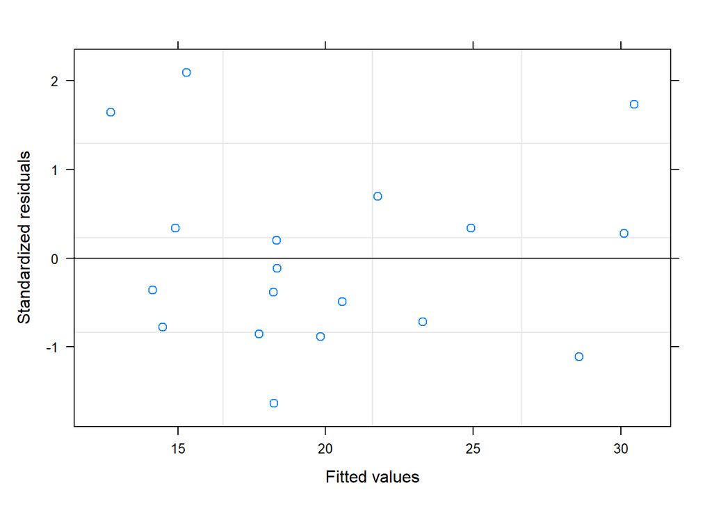

```r
#mod3.6<- update(mod3.5, ~.-temperature)
#summary(mod3.6)
#anova(mod3.5,mod3.6) # significant.. 0.0136 so we cannot remove more parameters and final model is 3.5
plot(mod3.5) #check for homogeneity of variances (data points should have similar vertical spread along the x-axis)
```

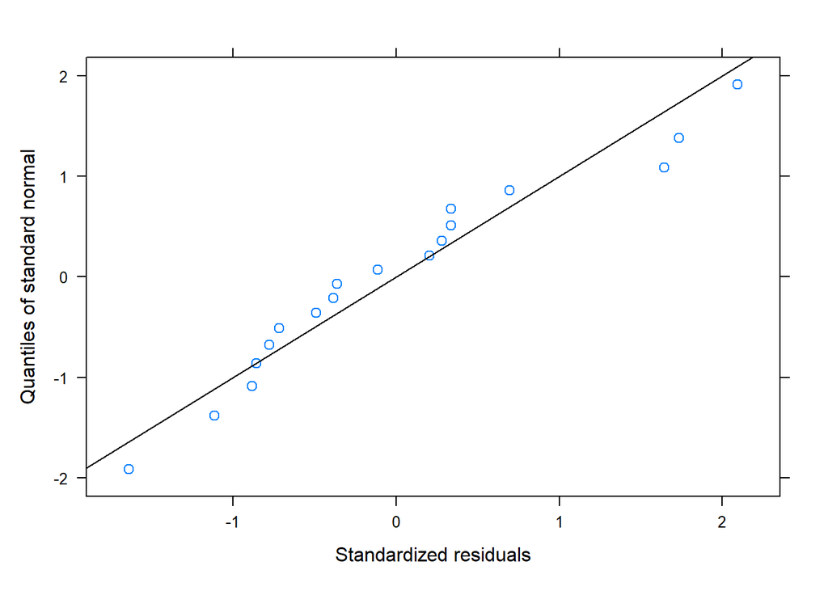

```r
qqnorm(mod3.5, ~resid(.,type="p"), abline=c(0,1)) #check for normality of residuals (should not be completely off the line)
```

```r
r.squaredGLMM(mod3.5)
```

```
##            R2m       R2c
## [1,] 0.7429521 0.7429521
```

#2d Plotting

```r
# plot model for abundance vs. canopy cover
mod_can<-lme(species_abund ~ canopy_cover, random = (~1|site), data=dat, method="ML")
r.squaredGLMM(mod_can)
```

```
##            R2m       R2c
## [1,] 0.3208035 0.5312365
```

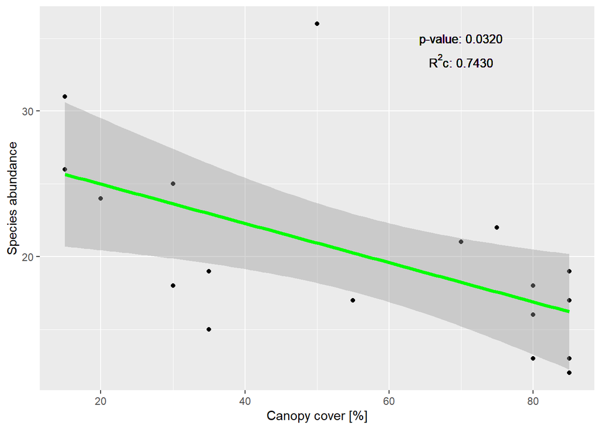

```r
ggplot(dat, aes(x = canopy_cover, y = species_abund))+
  geom_point() +
  geom_smooth(method = lm, se = TRUE, colour = 'green', size = 1.5) +
  geom_text(x=70, y=35, label="p-value: 0.0320", size=3.5) +
  geom_text(x=70,y=33.5, label=expression(paste("R"^2,"c: 0.7430")), size=3.5) +
  labs(x="Canopy cover [%]", y="Species abundance")
```

```r
 #plot species abundance vs. dbh_mean
mod_dbh<-lme(species_abund ~ dbh_mean, random = (~1|site), data=dat, method="ML")
r.squaredGLMM(mod_dbh)
```

```
##            R2m       R2c
## [1,] 0.5439872 0.5439872
```

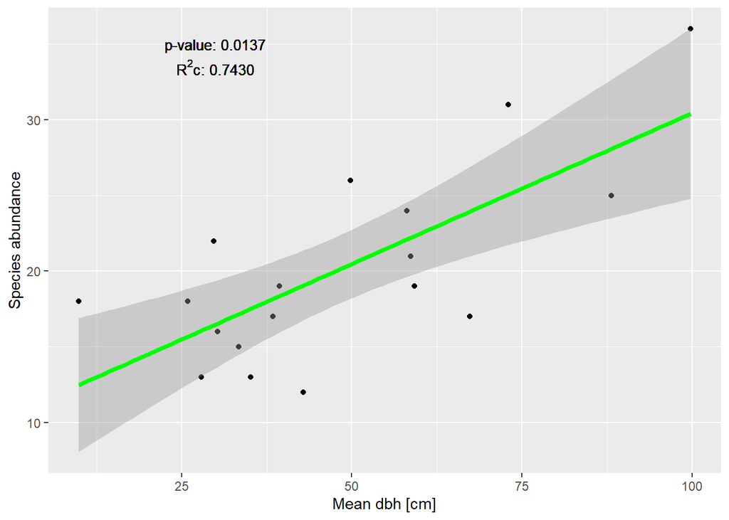

```r
ggplot(dat, aes(x = dbh_mean, y = species_abund))+
  geom_point() +
  geom_smooth(method = lm, se = TRUE, colour = 'green', size = 1.5) +
  geom_text(x=30, y=35, label="p-value: 0.0137", size=3.5) +
  geom_text(x=30,y=33.5, label=expression(paste("R"^2,"c: 0.7430")), size=3.5) +
  labs(x="Mean dbh [cm]", y="Species abundance")
```

```r
### MIXED EFFECTS MODEL WITH RAREFIED RICHNESS
mod4 <- lme(rarefied_richness ~ category*size + canopy_cover + n_tree_spec + n_tree_ind + dbh_mean + n_microhabitats + temperature, random = (~1|site), data=dat, method="ML") #initial, full model with all potential predictor variables
summary(mod4)
```

```
## Linear mixed-effects model fit by maximum likelihood
##   Data: dat
##        AIC      BIC    logLik
##   58.82988 69.51434 -17.41494
##
## Random effects:
##  Formula: ~1 | site
##          (Intercept)  Residual
## StdDev: 1.945884e-05 0.6367095
##
## Fixed effects:  rarefied_richness ~ category * size + canopy_cover + n_tree_spec +      n_tree_ind + dbh_mean + n_microhabitats + temperature
##                       Value Std.Error DF   t-value p-value
## (Intercept)        9.447534 2.9017160  7  3.255844  0.0139
## categorypark      -0.324162 1.6172023  1 -0.200446  0.8741
## size              -0.000690 0.0065679  1 -0.105015  0.9334
## canopy_cover      -0.009385 0.0152341  7 -0.616052  0.5574
## n_tree_spec       -0.239581 0.1861543  7 -1.287001  0.2390
## n_tree_ind        -0.023317 0.0899256  7 -0.259293  0.8029
## dbh_mean           0.015162 0.0163914  7  0.924993  0.3857
## n_microhabitats   -0.019605 0.0519662  7 -0.377270  0.7172
## temperature       -0.038946 0.0961492  1 -0.405056  0.7550
## categorypark:size  0.035628 0.0313803  1  1.135373  0.4597
##  Correlation:
##                   (Intr) ctgryp size   cnpy_c n_tr_s n_tr_n dbh_mn n_mcrh
## categorypark      -0.450
## size              -0.383  0.726
## canopy_cover      -0.622  0.338  0.026
## n_tree_spec       -0.316 -0.403 -0.319  0.131
## n_tree_ind        -0.497  0.146 -0.036  0.142  0.430
## dbh_mean          -0.151 -0.473 -0.134  0.020  0.173  0.126
## n_microhabitats   -0.304  0.196  0.084  0.068  0.013 -0.148 -0.412
## temperature       -0.306  0.294  0.358  0.148 -0.408 -0.528 -0.126  0.504
## categorypark:size -0.004 -0.164 -0.054  0.196 -0.348 -0.514  0.102  0.324
##                   tmprtr
## categorypark
## size
## canopy_cover
## n_tree_spec
## n_tree_ind
## dbh_mean
## n_microhabitats
## temperature
## categorypark:size  0.544
##
## Standardized Within-Group Residuals:
##        Min         Q1        Med         Q3        Max
## -2.1877031 -0.4447040  0.1760579  0.6684129  1.9167774
##
## Number of Observations: 18
## Number of Groups: 6
```

```r
mod4.1 <- stepAIC(mod4) #model simplification based on AIC-value of the model
```

```
## Start:  AIC=58.83
## rarefied_richness ~ category * size + canopy_cover + n_tree_spec +
##     n_tree_ind + dbh_mean + n_microhabitats + temperature
##
##                   Df    AIC
## - n_tree_ind       1 56.981
## - n_microhabitats  1 57.147
## - temperature      1 57.195
## - canopy_cover     1 57.664
## - dbh_mean         1 58.659
## <none>               58.830
## - category:size    1 59.519
## - n_tree_spec      1 60.217
##
## Step:  AIC=56.98
## rarefied_richness ~ category + size + canopy_cover + n_tree_spec +
##     dbh_mean + n_microhabitats + temperature + category:size
##
##                   Df    AIC
## - n_microhabitats  1 55.370
## - canopy_cover     1 55.729
## - temperature      1 55.866
## - dbh_mean         1 56.949
## <none>               56.981
## - category:size    1 57.793
## - n_tree_spec      1 58.393
##
## Step:  AIC=55.37
## rarefied_richness ~ category + size + canopy_cover + n_tree_spec +
##     dbh_mean + temperature + category:size
##
##                 Df    AIC
## - temperature    1 53.893
## - canopy_cover   1 54.017
## - dbh_mean       1 54.952
## <none>             55.370
## - n_tree_spec    1 56.583
## - category:size  1 56.961
##
## Step:  AIC=53.89
```

[output cut: 12 more lines]

```
##     category:size
##
##                 Df    AIC
## - dbh_mean       1 52.136
## <none>             52.295
## - n_tree_spec    1 54.053
## - category:size  1 54.782
##
## Step:  AIC=52.14
## rarefied_richness ~ category + size + n_tree_spec + category:size
##
##                 Df    AIC
## <none>             52.136
## - category:size  1 53.379
## - n_tree_spec    1 54.605
```

```r
summary(mod4.1) #final model which includes only the most important predictors
```

```
## Linear mixed-effects model fit by maximum likelihood
##   Data: dat
##        AIC     BIC   logLik
##   52.13579 58.3684 -19.0679
##
## Random effects:
##  Formula: ~1 | site
##          (Intercept)  Residual
## StdDev: 2.444494e-05 0.6979478
##
## Fixed effects:  rarefied_richness ~ category + size + n_tree_spec + category:size
##                       Value Std.Error DF   t-value p-value
## (Intercept)        7.803922 0.8477467 11  9.205488  0.0000
## categorypark       1.142705 0.9611518  2  1.188892  0.3565
## size               0.001719 0.0049856  2  0.344833  0.7631
## n_tree_spec       -0.267011 0.1296074 11 -2.060150  0.0638
## categorypark:size  0.033118 0.0193783  2  1.709046  0.2296
##  Correlation:
##                   (Intr) ctgryp size   n_tr_s
## categorypark      -0.391
## size              -0.688  0.790
## n_tree_spec       -0.508 -0.519 -0.190
## categorypark:size  0.346 -0.278 -0.194 -0.285
##
## Standardized Within-Group Residuals:
##        Min         Q1        Med         Q3        Max
## -1.8703378 -0.3878931  0.3183945  0.6351161  1.5813899
##
## Number of Observations: 18
## Number of Groups: 6
```

```r
mod4.2<-update(mod4.1,~.-n_tree_spec)
summary(mod4.2)
```

```
## Linear mixed-effects model fit by maximum likelihood
##   Data: dat
##        AIC      BIC    logLik
##   54.60478 59.94701 -21.30239
##
## Random effects:
##  Formula: ~1 | site
##         (Intercept) Residual
## StdDev:   0.3534172 0.721987
##
## Fixed effects:  rarefied_richness ~ category + size + category:size
##                       Value Std.Error DF   t-value p-value
## (Intercept)        6.917136 0.9544546 12  7.247213  0.0000
## categorypark       0.114911 1.0736401  2  0.107030  0.9245
## size              -0.000234 0.0063966  2 -0.036657  0.9741
## categorypark:size  0.021750 0.0242765  2  0.895932  0.4648
##  Correlation:
##                   (Intr) ctgryp size
## categorypark      -0.889
## size              -0.927  0.824
## categorypark:size  0.244 -0.520 -0.263
##
## Standardized Within-Group Residuals:
##        Min         Q1        Med         Q3        Max
## -1.8890898 -0.2875619  0.1002405  0.7866405  1.5315412
##
## Number of Observations: 18
## Number of Groups: 6
```

```r
anova(mod4.1,mod4.2) # significant so final model is 4.1
```

```
##        Model df      AIC      BIC    logLik   Test L.Ratio p-value
## mod4.1     1  7 52.13579 58.36840 -19.06790
## mod4.2     2  6 54.60478 59.94701 -21.30239 1 vs 2 4.46899  0.0345
```

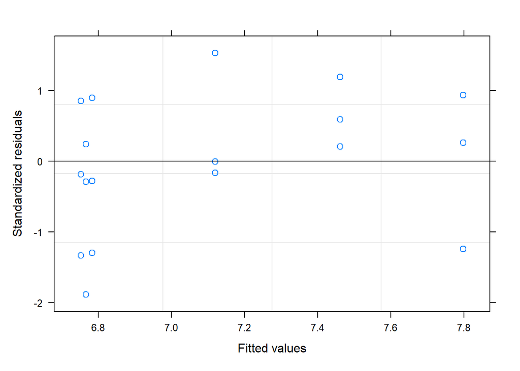

```r
# n_tree_spec: p-value 0.0638; size: p-value 0.7631
plot(mod4.2) #check for homogeneity of variances (data points should have similar vertical spread along the x-axis)
```

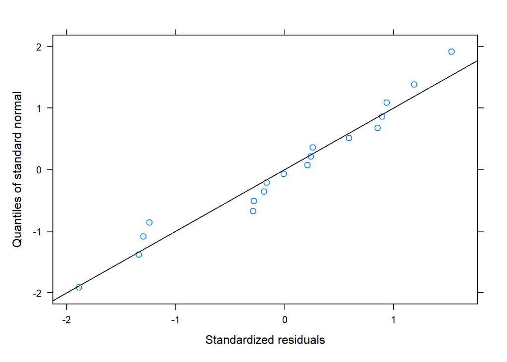

```r
qqnorm(mod4.2, ~resid(.,type="p"), abline=c(0,1)) #check for normality of residuals (should not be completely off the line)
```

```r
?qqnorm
```

```
## starting httpd help server ... done
```

```r
?metaMDS
?envfit
?ordiplot
?diversity
#plot(log(dbh_min)~rarefied_richness, data=dat, ylim=c(0,5))
#mod<-lm(rarefied_richness ~ log(dbh_min), data=dat, poly(degree = 2))
```

##2c Ordination with NMDS (to look for differences in species composition)

```r
nmd1 <- metaMDS(dat[,4:31], distance="horn", k=2) #NMDS analysis based on Morisita-Horn-Index as a dissimilarity measure
```

```
## *** Solution reached
```

```r
# orditkplot(nmd1, display = "species", col = "darkred", fill = NA, border = NA, cex = 0.6)
ordiplot(nmd1, choices = c(1, 2), type = "n") # ylim = c(-0.75, 0.5), xlim = c(-1.25, 1.3))
ordilabel(nmd1, display = "species", col = "darkred", fill = NA, border = NA, cex = 0.5)
points(nmd1, pch=c(16, 17)[as.numeric(as.factor(dat$category))], col = "darkblue") #add sampling points
legend("topright", pch = c(16, 17), c("Forest","Park"), col = "darkblue", cex = 0.7) #add legend
text(-1.4, -1.1, labels = "stress = 0.166", cex = 0.7)

ef <- envfit(nmd1, dat[,32:44]) #check for correlation of dissimilarity gradients with environmental variables
ef #results
```

```
##
## ***VECTORS
##
##                    NMDS1    NMDS2     r2 Pr(>r)
## canopy_cover     0.97465 -0.22373 0.5449  0.003 **
## n_tree_spec     -0.90910  0.41657 0.5815  0.002 **
## n_tree_ind       0.98935 -0.14558 0.1254  0.383
## dbh_min         -0.95996 -0.28014 0.0958  0.473
## dbh_min5        -0.66027 -0.75103 0.2847  0.075 .
## dbh_mean        -0.71933 -0.69467 0.3251  0.049 *
## dbh_max         -0.75683 -0.65361 0.3293  0.045 *
## dbh_median      -0.64467 -0.76446 0.2933  0.073 .
## dbh_sd          -0.90590  0.42350 0.5773  0.001 ***
## n_microhabitats  0.48729 -0.87324 0.2377  0.121
## latitude         0.66163 -0.74983 0.2294  0.161
## longitude        0.99957  0.02918 0.4694  0.013 *
## size             0.90393  0.42769 0.7395  0.001 ***
## ---
## Signif. codes:  0 '***' 0.001 '**' 0.01 '*' 0.05 '.' 0.1 ' ' 1
## Permutation: free
## Number of permutations: 999
```

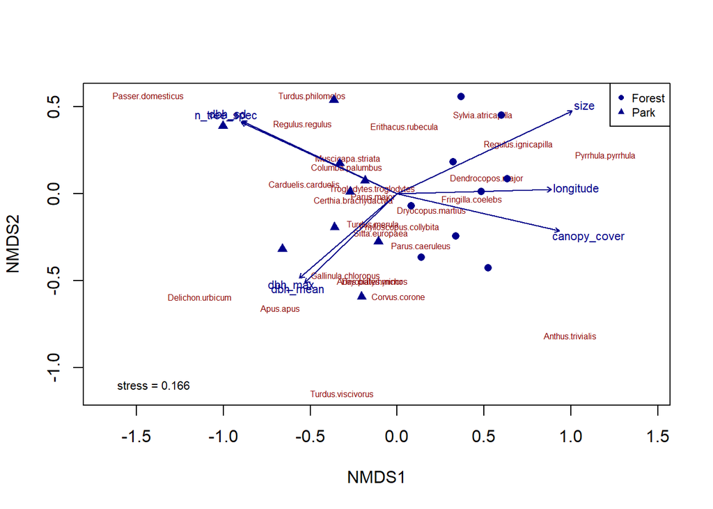

```r
plot(ef, p.max=0.05, col = "darkblue", cex = 0.7) #add significant environmental variables to the NMDS plot
```

Now the species accumulation curve is shown.

```r
SAC_park <- specaccum(subset(dat[,4:31], dat$category == "park"))
SAC_fore <- specaccum(subset(dat[,4:31], dat$category == "forest"))
```

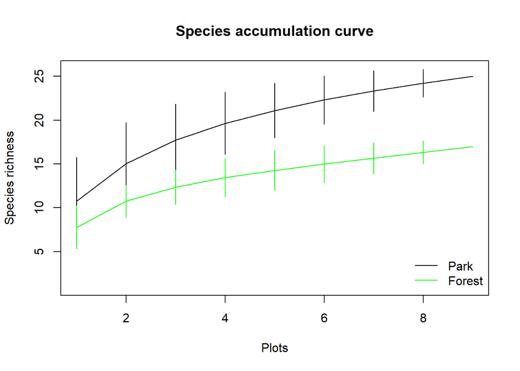

```r
plot(SAC_park, xlab = "Plots", ylab = "Species richness", main="Species accumulation curve")

plot(SAC_fore, xlab = "Plots", ylab = "Species richness", main="Species accumulation curve", col="green", add = T)
legend("bottomright", legend = c("Park","Forest"), col = c("black","green"), lwd=1, bty = "n")
```

Analysis of bird’s diversity and the variables measured from these two types of ecosystems.

```r
# parks <- read.csv("data/parks.csv", sep=";")
# forest <- read.csv("data/forest.csv", sep=";")
alpha <- specnumber(dat[,4:31]) # or use the binary site-species matrix
gamma <- ncol(dat[,colSums(dat[,4:31])>0])

##Lande’s index  (beta) diversity
gamma - mean(alpha)
```

```
## [1] 38.72222
```

```r
##Whittaker’s index

#gamma/mean(alpha)


#For parks

alphap <- specnumber(park[,4:31])

gammap <- ncol(park[,colSums(park[,4:31]) > 0])

##Lande’s index
gammap - mean(alphap)
```

```
## [1] 31.22222
```

```r
##Whittaker’s index

#gammap/mean(alphap)

#For forest
alphaf <- specnumber(forest[,4:31])

gammaf <- ncol(park[,colSums(park[,4:31]) > 0])

##Lande’s index
gammaf - mean(alphaf)
```

```
## [1] 34.22222
```

```r
##Whittaker’s index

#gammaf/mean(alphaf)
```

The number of shared and unique species for a given for the two plots combine and separated.

```r
beta_virt <- betadiver(dat[,4:31], method = NA)
# a
beta_virt$a
```

```
##     1  2  3  4  5  6  7  8  9 10 11 12 13 14 15 16 17
## 2   7
## 3   7  9
## 4   4  5  4
## 5   6  6  6  5
## 6   5  5  7  4  5
## 7   4  5  5  3  3  2
## 8   5  6  7  4  4  6  4
## 9   5  6  6  3  4  4  4  6
## 10  4  5  5  4  5  5  2  5  4
## 11  7  8  8  6  7  6  5  7  6  7
## 12  5  6  7  4  6  6  3  6  5  6  7
## 13  4  6  7  3  4  4  3  5  5  4  5  5
## 14  5  7  7  4  4  5  4  7  6  5  7  5  6
## 15  5  5  6  3  4  4  2  4  4  4  5  5  5  5
## 16  7  6  8  4  6  7  3  5  4  4  6  6  4  4  4
## 17  9  8  9  5  6  7  5  7  7  6  9  6  5  7  6  8
## 18  7  7  8  6  5  7  4  7  6  5  7  6  5  6  6  8 11
```

```r
beta_virt$b
```

```
##     1  2  3  4  5  6  7  8  9 10 11 12 13 14 15 16 17
## 2   5
## 3   7  5
## 4   3  2  3
## 5   1  1  1  2
## 6   4  4  2  5  4
## 7   2  1  1  3  3  4
## 8   4  3  2  5  5  3  5
## 9   2  1  1  4  3  3  3  1
## 10  3  2  2  3  2  2  5  2  3
## 11  3  2  2  4  3  4  5  3  4  3
## 12  3  2  1  4  2  2  5  2  3  2  1
## 13  3  1  0  4  3  3  4  2  2  3  2  2
## 14  3  1  1  4  4  3  4  1  2  3  1  3  2
## 15  4  4  3  6  5  5  7  5  5  5  4  4  4  4
## 16  2  3  1  5  3  2  6  4  5  5  3  3  5  5  5
## 17  4  5  4  8  7  6  8  6  6  7  4  7  8  6  7  5
## 18  7  7  6  8  9  7 10  7  8  9  7  8  9  8  8  6  3
```

```r
beta_virt$c
```

```
##     1  2  3  4  5  6  7  8  9 10 11 12 13 14 15 16 17
## 2   4
## 3   4  3
## 4   7  7 10
## 5   5  6  8  2
## 6   6  7  7  3  2
## 7   7  7  9  4  4  7
## 8   6  6  7  3  3  3  2
## 9   6  6  8  4  3  5  2  3
## 10  7  7  9  3  2  4  4  4  3
## 11  4  4  6  1  0  3  1  2  1  0
## 12  6  6  7  3  1  3  3  3  2  1  3
## 13  7  6  7  4  3  5  3  4  2  3  5  3
## 14  6  5  7  3  3  4  2  2  1  2  3  3  1
## 15  6  7  8  4  3  5  4  5  3  3  5  3  2  3
## 16  4  6  6  3  1  2  3  4  3  3  4  2  3  4  5
## 17  2  4  5  2  1  2  1  2  0  1  1  2  2  1  3  1
## 18  4  5  6  1  2  2  2  2  1  2  3  2  2  2  3  1  2
```

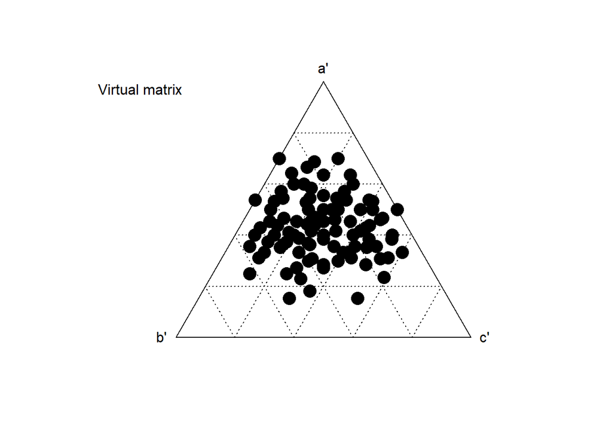

```r
plot(betadiver(dat[,4:31], method=NA), pch = 16, cex = 2,)
legend("topleft", legend = "Virtual matrix", bty = "n")
```

```r
beta_virtp <- betadiver(park, method = NA)
# a
beta_virtp$a
```

```
##     1  2  3 13 14 15 16 17
## 2  NA
## 3  NA NA
## 13 NA NA NA
## 14 NA NA NA NA
## 15 NA NA NA NA NA
## 16 NA NA NA NA NA NA
## 17 NA NA NA NA NA NA NA
## 18 NA NA NA NA NA NA NA NA
```

```r
beta_virtp$b
```

```
##     1  2  3 13 14 15 16 17
## 2  NA
## 3  NA NA
## 13 NA NA NA
## 14 NA NA NA NA
## 15 NA NA NA NA NA
## 16 NA NA NA NA NA NA
## 17 NA NA NA NA NA NA NA
## 18 NA NA NA NA NA NA NA NA
```

```r
beta_virtp$c
```

```
##     1  2  3 13 14 15 16 17
## 2  NA
## 3  NA NA
## 13 NA NA NA
## 14 NA NA NA NA
## 15 NA NA NA NA NA
## 16 NA NA NA NA NA NA
## 17 NA NA NA NA NA NA NA
## 18 NA NA NA NA NA NA NA NA
```

[figure not shown]

```r
plot(betadiver(park, method=NA), pch = 16, cex = 2,)
legend("topleft", legend = "Virtual matrix", bty = "n")
```

```r
#vennd iagram <- as alternative to show the overlap of shared species
```

Now the similarity between plots by Sorensen, Simpson and Jaccard

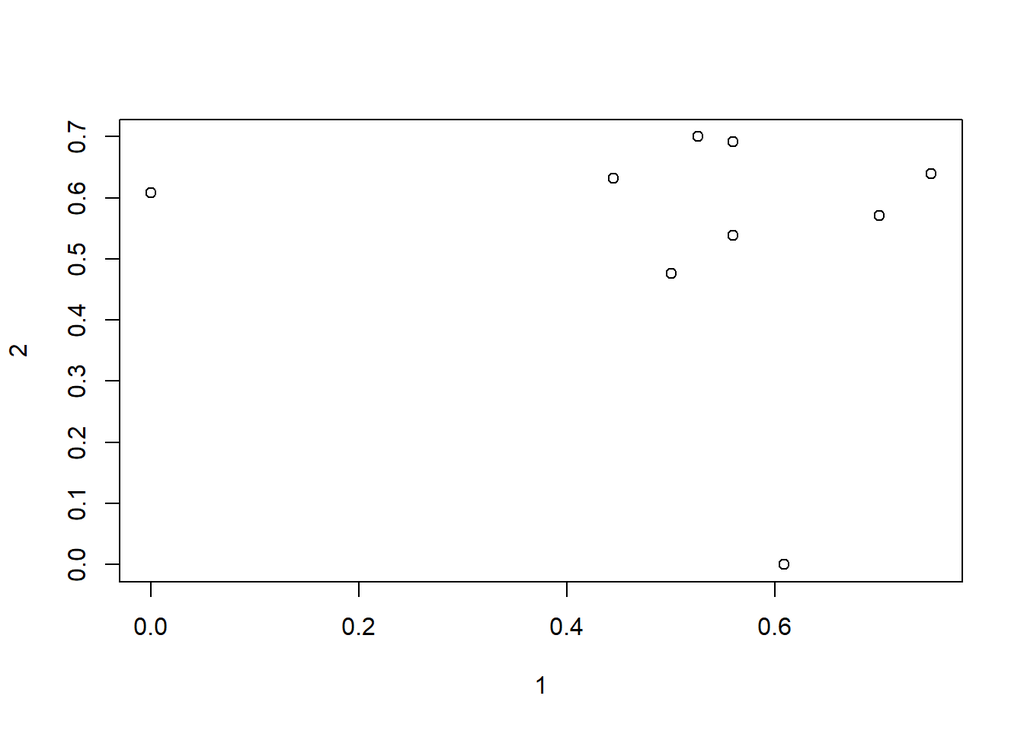

```r
#Sorensen similarity
sorparks <-  betadiver(park[,4:31], method = "sor")
sorensen <-  as.matrix(sorparks)[,]
plot(sorensen)
```

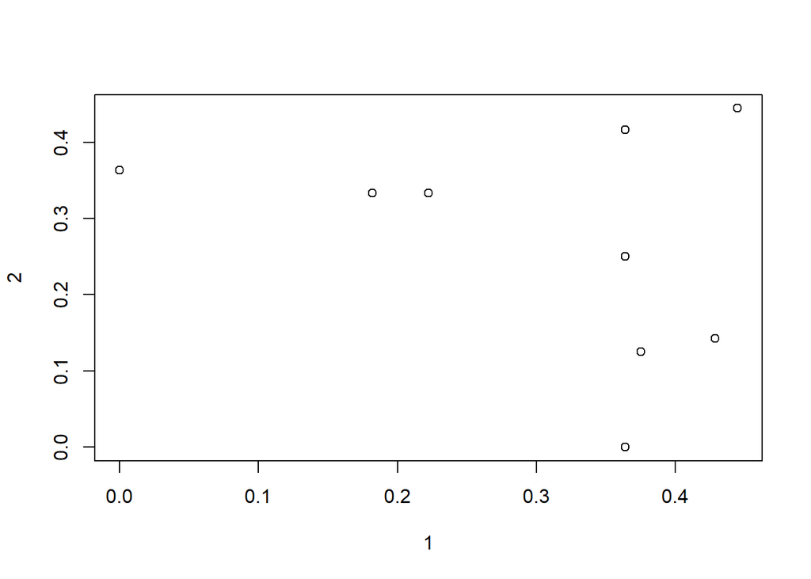

```r
#Simpson similarity
simpark<- betadiver(park[,4:31], method = "sim")
simpsonpark <- as.matrix(simpark)[,]
plot(simpsonpark)
```

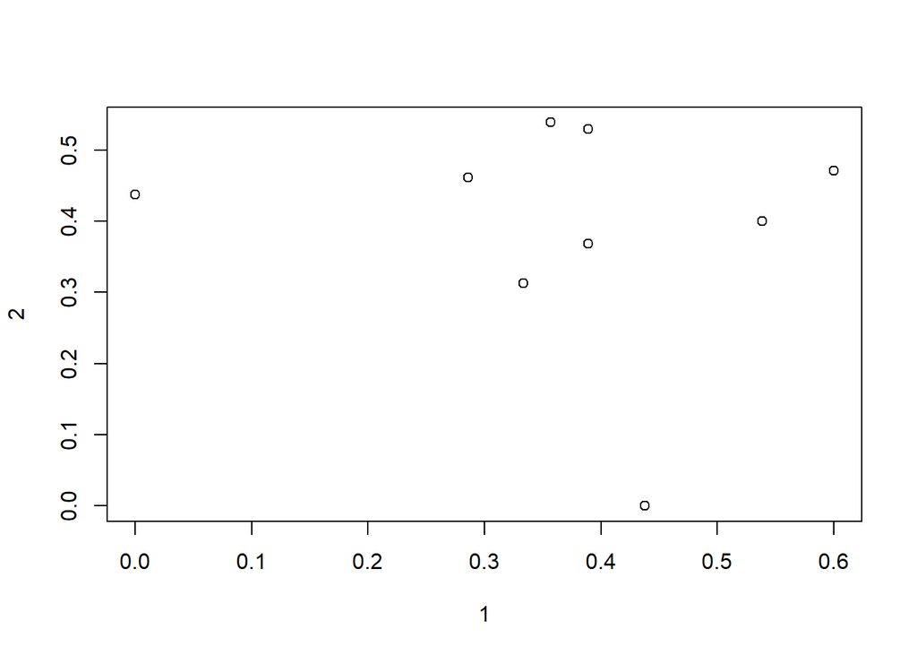

```r
# Jaccard similarity
jparks <- betadiver(park[,4:31], method = "j")
plot(as.matrix(jparks)[,])
```

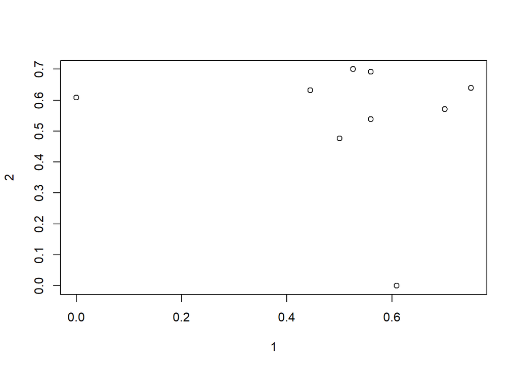

```r
#Sorensen similarity
sorforest <-  betadiver(forest[,4:31], method = "sor")
sorensenforest <-  as.matrix(sorforest)[,]
plot(sorensen)
```

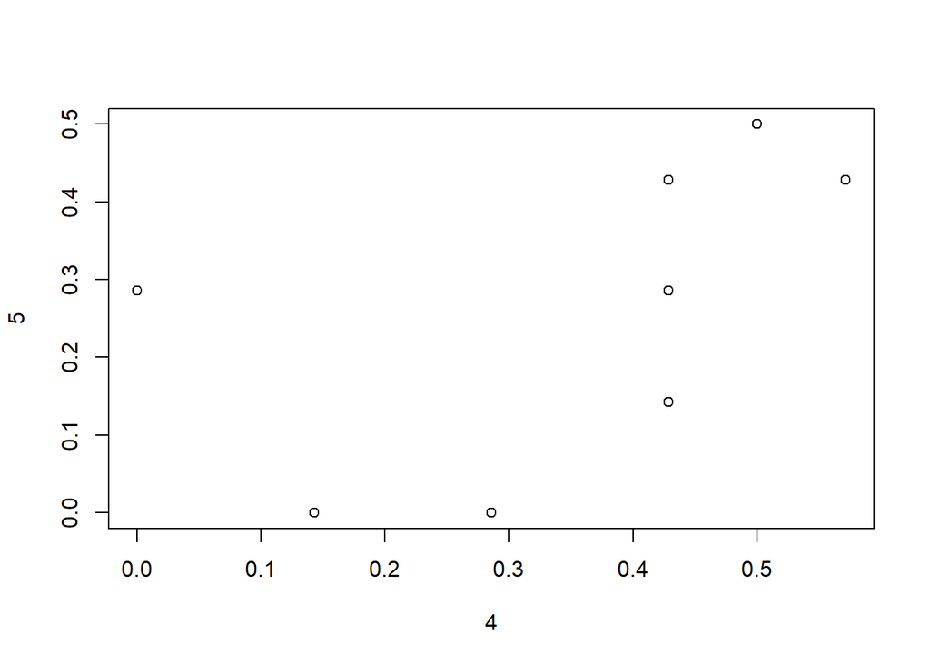

```r
#Simpson similarity
simf <- betadiver(forest[,4:31], method = "sim")
simpson <- as.matrix(simf)[,]
plot(simpson)
```

```r
# Jaccard similarity

jforest <- betadiver(forest[,4:31], method = "j")
as.matrix(jforest)[,]
```

```
##            4         5         6         7         8         9        10
## 4  0.0000000 0.5555556 0.3333333 0.3000000 0.3333333 0.2727273 0.4000000
## 5  0.5555556 0.0000000 0.4545455 0.3000000 0.3333333 0.4000000 0.5555556
## 6  0.3333333 0.4545455 0.0000000 0.1538462 0.5000000 0.3333333 0.4545455
## 7  0.3000000 0.3000000 0.1538462 0.0000000 0.3636364 0.4444444 0.1818182
## 8  0.3333333 0.3333333 0.5000000 0.3636364 0.0000000 0.6000000 0.4545455
## 9  0.2727273 0.4000000 0.3333333 0.4444444 0.6000000 0.0000000 0.4000000
## 10 0.4000000 0.5555556 0.4545455 0.1818182 0.4545455 0.4000000 0.0000000
## 11 0.5454545 0.7000000 0.4615385 0.4545455 0.5833333 0.5454545 0.7000000
## 12 0.3636364 0.6666667 0.5454545 0.2727273 0.5454545 0.5000000 0.6666667
##           11        12
## 4  0.5454545 0.3636364
## 5  0.7000000 0.6666667
## 6  0.4615385 0.5454545
## 7  0.4545455 0.2727273
## 8  0.5833333 0.5454545
## 9  0.5454545 0.5000000
## 10 0.7000000 0.6666667
## 11 0.0000000 0.6363636
## 12 0.6363636 0.0000000
```

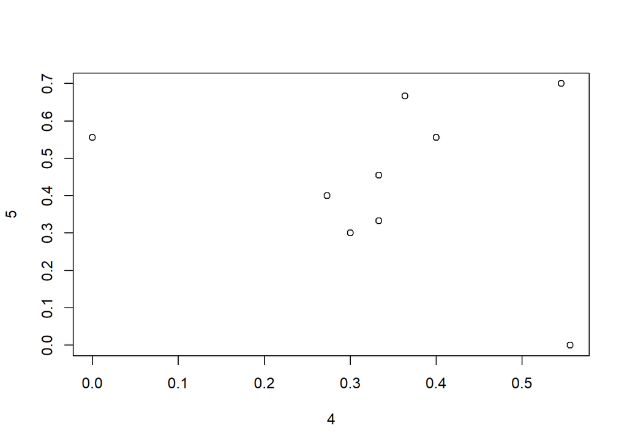

```r
plot(as.matrix(jforest)[,])
```

```r
#calculate mean of these similarities indices and compare between sites
```

RANK abundance curve <- takes abundant species per site and plot it against relative species abundance rank

```r
# Klosterpark
plot1_1 <- data.frame(sp = colnames(dat[,4:31]), ab = as.numeric(dat[1,4:31]))
plot1_2 <- data.frame(sp = colnames(dat[,4:31]), ab = as.numeric(dat[2,4:31]))
plot1_3 <- data.frame(sp = colnames(dat[,4:31]), ab = as.numeric(dat[3,4:31]))

plot1_12 <- merge(plot1_1, plot1_2, by = "sp")
plot1 <- merge(plot1_12, plot1_3, by = "sp")
plot1$abun <- plot1$ab.x + plot1$ab.y + plot1$ab
plot1 <- plot1[which(plot1$abun!=0),]
dim(plot1)
```

```
## [1] 20  5
```

```r
plot1$relabun <- plot1$abun * 100 / sum(plot1$abun)
plot1$rank <- rank(-plot1$relabun, ties.method = "random")
plot1 <- plot1[order(plot1$rank),]

# City Forest
plot2_1 <- data.frame(sp = colnames(dat[,4:31]), ab = as.numeric(dat[4,4:31]))
plot2_2 <- data.frame(sp = colnames(dat[,4:31]), ab = as.numeric(dat[5,4:31]))
plot2_3 <- data.frame(sp = colnames(dat[,4:31]), ab = as.numeric(dat[6,4:31]))

plot2_12 <- merge(plot2_1, plot2_2, by = "sp")
plot2 <- merge(plot2_12, plot2_3, by = "sp")
plot2$abun <- plot2$ab.x + plot2$ab.y + plot2$ab
plot2 <- plot2[which(plot2$abun!=0),]
dim(plot2)
```

```
## [1] 12  5
```

```r
plot2$relabun <- plot2$abun * 100 / sum(plot2$abun)
plot2$rank <- rank(-plot2$abun, ties.method = "random")
plot2 <- plot2[order(plot2$rank),]

# Forest Weende
plot3_1 <- data.frame(sp = colnames(dat[,4:31]), ab = as.numeric(dat[7,4:31]))
plot3_2 <- data.frame(sp = colnames(dat[,4:31]), ab = as.numeric(dat[8,4:31]))
plot3_3 <- data.frame(sp = colnames(dat[,4:31]), ab = as.numeric(dat[9,4:31]))

plot3_12 <- merge(plot3_1, plot3_2, by = "sp")
plot3 <- merge(plot3_12, plot3_3, by = "sp")
plot3$abun <- plot3$ab.x + plot3$ab.y + plot3$ab
plot3 <- plot3[which(plot3$abun!=0),]
dim(plot3)
```

```
## [1] 12  5
```

```r
plot3$relabun <- plot3$abun * 100 / sum(plot3$abun)
plot3$rank <- rank(-plot3$abun, ties.method = "random")
plot3 <- plot3[order(plot3$rank),]

# Forest Billingshäuser Schlucht
plot4_1 <- data.frame(sp = colnames(dat[,4:31]), ab = as.numeric(dat[10,4:31]))
plot4_2 <- data.frame(sp = colnames(dat[,4:31]), ab = as.numeric(dat[11,4:31]))
plot4_3 <- data.frame(sp = colnames(dat[,4:31]), ab = as.numeric(dat[12,4:31]))

plot4_12 <- merge(plot4_1, plot4_2, by = "sp")
plot4 <- merge(plot4_12, plot4_3, by = "sp")
plot4$abun <- plot4$ab.x + plot4$ab.y + plot4$ab
plot4 <- plot4[which(plot4$abun!=0),]
dim(plot4)
```

```
## [1] 11  5
```

```r
plot4$relabun <- plot4$abun * 100 / sum(plot4$abun)
plot4$rank <- rank(-plot4$abun, ties.method = "random")
plot4 <- plot4[order(plot4$rank),]

# Cheltenham Park
plot5_1 <- data.frame(sp = colnames(dat[,4:31]), ab = as.numeric(dat[13,4:31]))
plot5_2 <- data.frame(sp = colnames(dat[,4:31]), ab = as.numeric(dat[14,4:31]))
plot5_3 <- data.frame(sp = colnames(dat[,4:31]), ab = as.numeric(dat[15,4:31]))

plot5_12 <- merge(plot5_1, plot5_2, by = "sp")
plot5 <- merge(plot5_12, plot5_3, by = "sp")
plot5$abun <- plot5$ab.x + plot5$ab.y + plot5$ab
plot5 <- plot5[which(plot5$abun!=0),]
dim(plot5)
```

```
## [1] 13  5
```

```r
plot5$relabun <- plot5$abun * 100 / sum(plot5$abun)
plot5$rank <- rank(-plot5$abun, ties.method = "random")
plot5 <- plot5[order(plot5$rank),]

# City Cemetery
plot6_1 <- data.frame(sp = colnames(dat[,4:31]), ab = as.numeric(dat[16,4:31]))
plot6_2 <- data.frame(sp = colnames(dat[,4:31]), ab = as.numeric(dat[17,4:31]))
plot6_3 <- data.frame(sp = colnames(dat[,4:31]), ab = as.numeric(dat[18,4:31]))

plot6_12 <- merge(plot6_1, plot6_2, by = "sp")
plot6 <- merge(plot6_12, plot6_3, by = "sp")
plot6$abun <- plot6$ab.x + plot6$ab.y + plot6$ab
plot6 <- plot6[which(plot6$abun!=0),]
dim(plot6)
```

```
## [1] 16  5
```

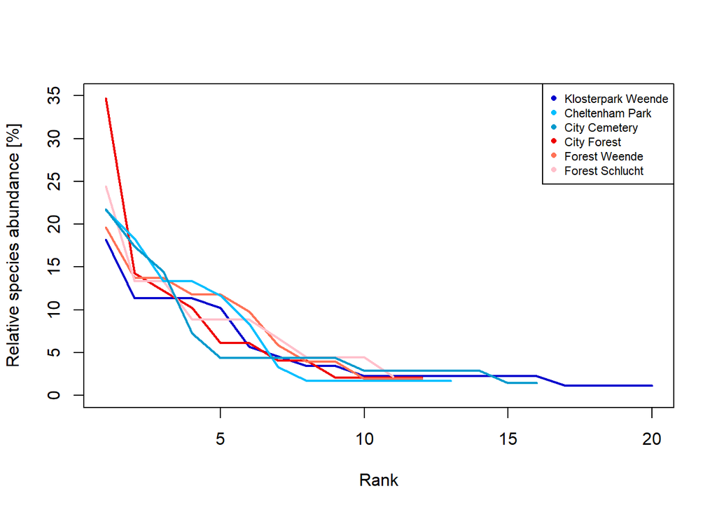

```r
plot6$relabun <- plot6$abun * 100 / sum(plot6$abun)
plot6$rank <- rank(-plot6$abun, ties.method = "random")
plot6 <- plot6[order(plot6$rank),]

# Plotting
plot(plot1$rank, plot1$relabun, type = "l",
     col = "blue3", pch = 16, lwd = 2,
     ylim = c(0, 35),
     xlab = "Rank", ylab = "Relative species abundance [%]")
points(plot2$rank, plot2$relabun, type = "l",
       col = "red2", pch = 16, lwd = 2)
points(plot3$rank, plot3$relabun, type = "l",
       col = "coral1", pch = 16, lwd = 2)
points(plot4$rank, plot4$relabun, type = "l",
       col = "pink", pch = 16, lwd = 2)
points(plot5$rank, plot5$relabun, type = "l",
       col = "deepskyblue", pch = 16, lwd = 2)
points(plot6$rank, plot6$relabun, type = "l",
       col = "deepskyblue3", pch = 16, lwd = 2)
legend("topright",legend = c("Klosterpark Weende", "Cheltenham Park", "City Cemetery", "City Forest", "Forest Weende", "Forest Schlucht"), col = c("blue3", "deepskyblue", "deepskyblue3", "red2", "coral1", "pink"), cex = 0.7, pch = 16)
```

```r
#library(wesanderson)
#library("RColorBrewer")

#par(mfrow = c(1, 1))
#plot1_1 <- data.frame(sp = colnames(dat[,4:31]), ab = as.numeric(dat[1,4:31]))

#plot1_1 <- plot1_1[which(plot1_1$ab!=0),]
#dim(plot1_1)

# Add rank of species in the first community
#plot1_1$rank <- rank(-plot1_1$ab, ties.method = "random")
# Ordering data before plotting
#plot1_1 <- plot1_1[order(plot1_1$rank), ]
# Plot
#plot(plot1_1$rank, plot1_1$ab, type = "b",
#   col = "coral", pch = 16, lwd = 1,
#   main = "RAD",
#   xlab = "Rank", ylab = "Abundances")



#plot1_2 <- data.frame(sp = colnames(dat[,4:31]), ab = as.numeric(dat[2,4:31]))
#plot1_2 <- plot1_2[which(plot1_2$ab!=0),]
#dim(plot1_2)

#plot1_2$rank <- rank(-plot1_2$ab, ties.method = "random")

#plot1_2 <- plot1_2[order(plot1_2$rank), ]
#points(plot1_2$rank, plot1_2$ab, type = "both",   col = "coral2", pch = 16)

#plot1_3 <- data.frame(sp = colnames(dat[,4:31]), ab = as.numeric(dat[3,4:31]))

#plot1_3 <- plot1_3[which(plot1_3$ab!=0),]
#dim(plot1_3)
#plot1_3$rank <- rank(-plot1_3$ab, ties.method = "random")
#plot1_3 <- plot1_3[order(plot1_3$rank), ]
#points(plot1_3$rank, plot1_3$ab, type = "b",
# col = "coral3", pch = 16, lwd = 1)


#plot2_1 <- data.frame(sp = colnames(dat[,4:31]),
#                  ab = as.numeric(dat[4,4:31]))
#plot2_1 <- plot2_1[which(plot2_1$ab!=0),]
#dim(plot2_1)
#$rank <- rank(-plot2_1$ab, ties.method = "random")
#plot2_1 <- plot2_1[order(plot2_1$rank), ]
#points(plot2_1$rank, plot2_1$ab, type = "b",
#   col = "aquamarine", pch = 16, lwd = 1)



#plot2_2 <- data.frame(sp = colnames(dat[,4:31]),
#                    ab = as.numeric(dat[5,4:31]))
#plot2_2 <- plot2_2[which(plot2_2$ab!=0),]
#dim(plot2_2)
#plot2_2$rank <- rank(-plot2_2$ab, ties.method = "random")
#plot2_2 <- plot2_2[order(plot2_2$rank), ]
#points(plot2_2$rank, plot2_2$ab, type = "b",
#  col = "aquamarine3", pch = 16, lwd = 1)

#plot2_3 <- data.frame(sp = colnames(dat[,4:31]),
#                ab = as.numeric(dat[6,4:31]))
#plot2_3 <- plot2_3[which(plot2_3$ab!=0),]
#dim(plot2_3)
#plot2_3$rank <- rank(-plot2_3$ab, ties.method = "random")
#plot2_3 <- plot2_3[order(plot2_3$rank), ]
#points(plot2_3$rank, plot2_3$ab, type = "b",
#  col = "aquamarine4", pch = 16, lwd = 1)

#plot3_1 <- data.frame(sp = colnames(dat[,4:31]),
#                    ab = as.numeric(dat[7,4:31]))
#plot3_1 <- plot3_1[which(plot3_1$ab!=0),]
#dim(plot3_1)
#plot3_1$rank <- rank(-plot3_1$ab, ties.method = "random")
#plot3_1 <- plot3_1[order(plot3_1$rank), ]
#points(plot3_1$rank, plot3_1$ab, type = "b",
#  col = "antiquewhite", pch = 16, lwd = 1)

#plot3_2 <- data.frame(sp = colnames(dat[,4:31]),
#                ab = as.numeric(dat[8,4:31]))
#plot3_2 <- plot3_2[which(plot3_1$ab!=0),]
#(plot3_2)
#plot3_2$rank <- rank(-plot3_2$ab, ties.method = "random")
#plot3_2 <- plot3_2[order(plot3_2$rank), ]
#points(plot3_2$rank, plot3_2$ab, type = "b",
#   col = "antiquewhite3", pch = 16, lwd = 1)


#plot3_3 <- data.frame(sp = colnames(dat[,4:31]),
#                   ab = as.numeric(dat[9,4:31]))
#plot3_3 <- plot3_3[which(plot3_1$ab!=0),]
#dim(plot3_3)
#plot3_3$rank <- rank(-plot3_3$ab, ties.method = "random")
#plot3_3 <- plot3_3[order(plot3_3$rank), ]
#points(plot3_3$rank, plot3_3$ab, type = "b",
#   col = "antiquewhite4", pch = 16, lwd = 1)


#plot4_1 <- data.frame(sp = colnames(dat[,4:31]),
#    ab = as.numeric(dat[10,4:31]))
#plot4_1 <- plot4_1[which(plot4_1$ab!=0),]
#dim(plot4_1)
#plot4_1$rank <- rank(-plot4_1$ab, ties.method = "random")
#plot4_1 <- plot4_1[order(plot4_1$rank), ]
#points(plot4_1$rank, plot4_1$ab, type = "b",
#    col = "brown1", pch = 16, lwd = 1)

#plot4_2 <- data.frame(sp = colnames(dat[,4:31]),
#                    ab = as.numeric(dat[11,4:31]))
#plot4_2 <- plot4_2[which(plot4_2$ab!=0),]
#dim(plot4_2)
#plot4_2$rank <- rank(-plot4_2$ab, ties.method = "random")
#plot4_2 <- plot4_2[order(plot4_1$rank), ]
#points(plot4_2$rank, plot4_2$ab, type = "b",
#   col = "brown4", pch = 16, lwd = 1)

#plot4_3 <- data.frame(sp = colnames(dat[,4:31]),
# ab = as.numeric(dat[12,4:31]))
#plot4_3 <- plot4_3[which(plot4_3$ab!=0),]
#dim(plot4_3)
#plot4_3$rank <- rank(-plot4_3$ab, ties.method = "random")
#plot4_3 <- plot4_3[order(plot4_3$rank), ]
#points(plot4_3$rank, plot4_3$ab, type = "b",
#     col = "brown2", pch = 16, lwd = 1)


#plot5_1 <- data.frame(sp = colnames(dat[,4:31]),
#                     ab = as.numeric(dat[13,4:31]))
#plot5_1 <- plot5_1[which(plot5_1$ab!=0),]
#dim(plot5_1)
#plot5_1$rank <- rank(-plot5_1$ab, ties.method = "random")
#plot5_1 <- plot5_1[order(plot5_1$rank), ]
#points(plot5_1$rank, plot5_1$ab, type = "b",
#   col = "chartreuse", pch = 16, lwd = 1)


#plot5_2 <- data.frame(sp = colnames(dat[,4:31]),
#                       ab = as.numeric(dat[14,4:31]))
#plot5_2 <- plot5_2[which(plot5_2$ab!=0),]
#dim(plot5_2)
#plot5_2$rank <- rank(-plot5_2$ab, ties.method = "random")
#plot5_2 <- plot5_2[order(plot5_2$rank), ]
#points(plot5_2$rank, plot5_2$ab, type = "b",
#   col = "chartreuse3", pch = 16, lwd = 1)

#plot5_3 <- data.frame(sp = colnames(dat[,4:31]),
#                      ab = as.numeric(dat[15,4:31]))
#plot5_3 <- plot5_3[which(plot5_3$ab!=0),]
#dim(plot5_3)
#plot5_3$rank <- rank(-plot5_3$ab, ties.method = "random")
#plot5_3 <- plot5_3[order(plot5_3$rank), ]
#points(plot5_3$rank, plot5_3$ab, type = "b",
#   col = "chartreuse4", pch = 16, lwd = 1)


#plot6_1 <- data.frame(sp = colnames(dat[,4:31]),
#                    ab = as.numeric(dat[16,4:31]))
#plot6_1 <- plot6_1[which(plot6_1$ab!=0),]
#dim(plot6_1)
#plot6_1$rank <- rank(-plot6_1$ab, ties.method = "random")
#plot6_1 <- plot6_1[order(plot6_1$rank), ]
#points(plot6_1$rank, plot6_1$ab, type = "b",
#    col = "cadetblue", pch = 16, lwd = 1)


#plot6_2 <- data.frame(sp = colnames(dat[,4:31]),
#                      ab = as.numeric(dat[17,4:31]))
#plot6_2 <- plot6_2[which(plot6_2$ab!=0),]
#dim(plot6_2)
#plot6_2$rank <- rank(-plot6_2$ab, ties.method = "random")
#plot6_2 <- plot6_2[order(plot6_2$rank), ]
#points(plot6_2$rank, plot6_2$ab, type = "b",
#   col = "cadetblue3", pch = 16, lwd = 1)


#plot6_3 <- data.frame(sp = colnames(dat[,4:31]),
#                      ab = as.numeric(dat[18,4:31]))
#plot6_3 <- plot6_3[which(plot6_3$ab!=0),]
#dim(plot6_3)
#plot6_3$rank <- rank(-plot6_3$ab, ties.method = "random")
#plot6_3 <- plot6_3[order(plot6_3$rank), ]
#points(plot6_3$rank, plot6_3$ab, type = "b",
#   col = "cadetblue4", pch = 16, lwd = 1)


#legend( "topright",legend=c("1_1 (11 species)", "1_2 (12 species)", "1_3 (14 species)", "2_1 (7 species)", "2_2 (7 species)", "2_3 (9 species)", "3_1 (6 species)", "3_2 (6 species)", "3_3 (6 species)", "4_1 (7 species)", "4_2 (10 species)", "4_3 (8 species)", "5_1 (7 species)", "5_2 (8 species)", "5_3 (9 species)", "6_1 (9 species)", "6_2 (13 species)", "6_3 (14 species)"), col= c("coral", "coral2", "coral3", "aquamarine", "aquamarine3", "aquamarine4","antiquewhite", "antiquewhite3","antiquewhite4","brown1", "brown4,brown2", "chartreuse","chartreuse3", "chartreuse4", "cadetblue", "cadetblue3", "cadetblue4"), cex = 0.7)

#datplot <- bind_rows(plot1_1,plot1_2,plot1_3)


#plot6_2$plot <- "plot6_2"

#plot1 <- cbind(plot1_1[,1:3], plot1_2[,1:3], plot1_3[,1:3])


#ggplot()+
#  geom_line(aes(rank, ab, colour="plot1_1"), data=plot1_1)+
#geom_line(aes(rank, ab, colour="plot1_2"), data=plot1_2)+
#geom_line(aes(rank, ab, colour="plot1_3"), data=plot1_3)+
#geom_line(aes(rank, ab, colour="plot2_1"), data=plot2_1)+
#geom_line(aes(rank, ab, colour="plot2_2"), data=plot2_2)+
#geom_line(aes(rank, ab, colour="plot2_3"), data=plot2_3)+
#geom_line(aes(rank, ab, colour="plot3_1"), data=plot3_1)+
#geom_line(aes(rank, ab, colour="plot3_2"), data=plot3_2)+
#geom_line(aes(rank, ab, colour="plot3_3"), data=plot3_3)+
#geom_line(aes(rank, ab, colour="plot4_1"), data=plot4_1)+
#geom_line(aes(rank, ab, colour="plot4_2"), data=plot4_2)+
#geom_line(aes(rank, ab, colour="plot4_3"), data=plot4_3)+
#geom_line(aes(rank, ab, colour="plot5_1"), data=plot5_1)+
#geom_line(aes(rank, ab, colour="plot5_2"), data=plot5_2)+
#geom_line(aes(rank, ab, colour="plot5_3"), data=plot5_3)+
#geom_line(aes(rank, ab, colour="plot6_1"), data=plot6_1)+
#geom_line(aes(rank, ab, colour="plot6_2"), data=plot6_2)+
#geom_line(aes(rank, ab, colour="plot6_3"), data=plot6_3)+
#  labs(y = "Abundance", x = "Rank", color = "")

#rank abundance curve per site
#datsite<-aggregate(data=dat[,1:31],.~site, sum)
```

```r
datp_NMDS <- metaMDS(jparks, k = 2)
```

```
## *** No convergence -- monoMDS stopping criteria:
##     18: stress ratio > sratmax
##      2: scale factor of the gradient < sfgrmin
```

```r
datf_NMDS <- metaMDS(jforest, k=2)
```

```
## *** Solution reached
```

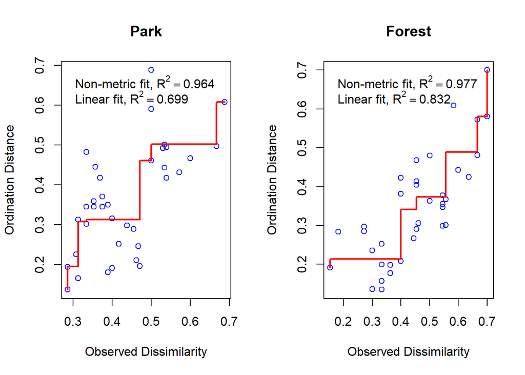

```r
par(mfrow = c(1, 2))
stressplot(datp_NMDS, main = "Park")
stressplot(datf_NMDS, main = "Forest")
```

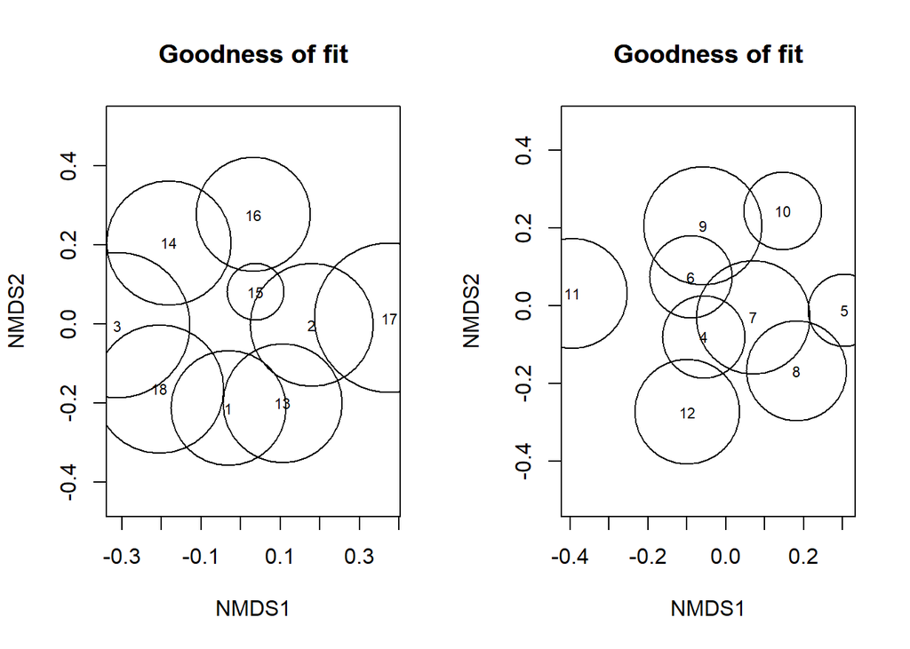

```r
par(mfrow = c(1, 2))
plot(datp_NMDS, display = "sites", type = "t", main = "Goodness of fit")
points(datp_NMDS, display = "sites", cex = goodness(datp_NMDS)*200)
title(main = "Goodness of fit")

plot(datf_NMDS, display = "sites", type = "t", main = "Goodness of fit")
points(datf_NMDS, display = "sites", cex = goodness(datf_NMDS)*200)
title(main = "Goodness of fit")
```

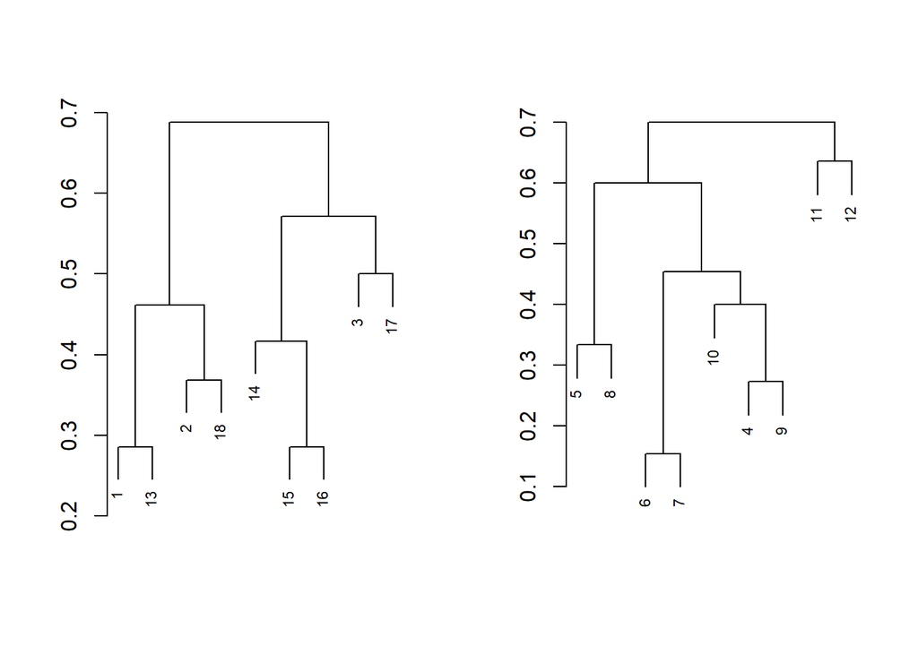

```r
datpclust <- hclust(jparks, method = "complete")
plot(datpclust, xlab = "", cex = 0.7, ann = FALSE)
abline(h = 0.78, lwd = 2, col = "black", lty = 2)

datfclust <- hclust(jforest, method = "complete")
plot(datfclust, xlab = "", cex = 0.7, ann = FALSE)
abline(h = 0.78, lwd = 2, col = "black", lty = 2)
```

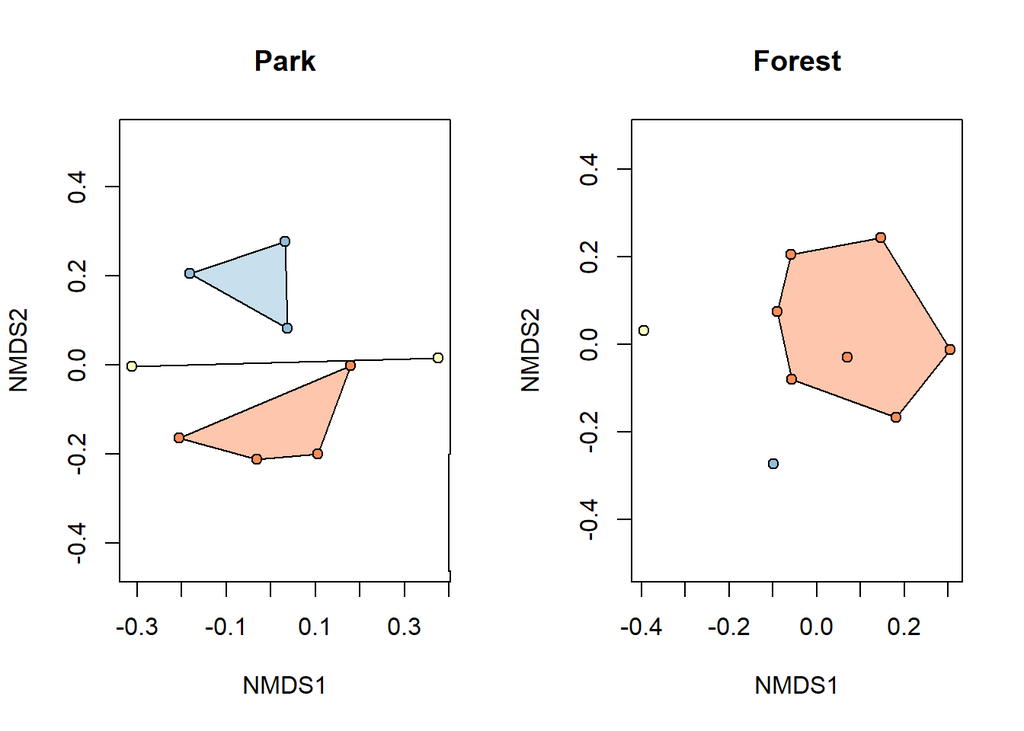

```r
datpclust_3 <- cutree(datpclust, k = 3)

plot(datp_NMDS, display = "sites", type = "n", main = "Park")
ordihull(datp_NMDS, groups = datpclust_3,
         draw = "polygon", col = c("#fc8d59", "#ffffbf", "#91bfdb"),
         label = FALSE)
points(datp_NMDS, display = "sites", pch = 21, col = "black",
       bg = c("#fc8d59", "#ffffbf", "#91bfdb")[datpclust_3])
legend(x = 0.4, y = -0.2, legend = c(paste0("Cl. ", seq(1:3))),
       col = c("#fc8d59", "#ffffbf", "#91bfdb"), pch = 16)

datfclust_3 <- cutree(datfclust, k = 3)

plot(datf_NMDS, display = "sites", type = "n", main = "Forest")
ordihull(datf_NMDS, groups = datfclust_3,
         draw = "polygon", col = c("#fc8d59", "#ffffbf", "#91bfdb"),
         label = FALSE)
points(datf_NMDS, display = "sites", pch = 21, col = "black",
       bg = c("#fc8d59", "#ffffbf", "#91bfdb")[datfclust_3])
legend(x = 0.4, y = -0.2, legend = c(paste0("Cl. ", seq(1:3))),
       col = c("#fc8d59", "#ffffbf", "#91bfdb"), pch = 16)
```

Shannon diversity index

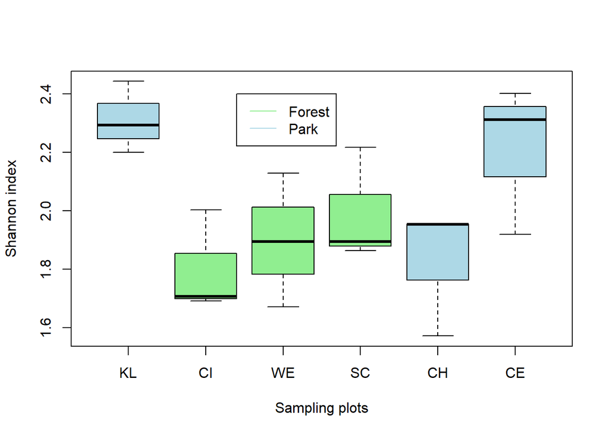

```r
H <- diversity(dat[,4:31], index = "shannon")
plot(H~dat$site, xlab="Sampling plots", xaxt="n", ylab = "Shannon index", col=c("lightblue","lightgreen","lightgreen","lightgreen","lightblue","lightblue"))
axis(1, at=1:6, labels=c("KL","CI","WE","SC","CH","CE"))
legend(2.4, 2.4,legend=c("Forest", "Park"), col=c("lightgreen", "lightblue"), lty=1, cex=1)
```